# Untitled

*Examen de la variable atm*: Elle décrit les conditions atmospherique au moment de l’accident

```r
table(accidents$atm, useNA = "ifany")
```

```
##
##     1     2     3     4     5     6     7     8     9
## 41802  6779  1449   233   529   169   817  2374   250
```

*Le resultat sous forme de tableau*

```r
library(knitr)

atm <- data.frame(
  Code = as.character(1:9),
  `Conditions atmosphériques` = c("Normale", "Pluie légère", "Pluie forte",
                                  "Neige – grêle", "Brouillard – fumée",
                                  "Vent fort – tempête", "Temps éblouissant",
                                  "Temps couvert", "Autre"),
  Accidents = c(41802, 6779, 1449, 233, 529, 169, 817, 2374, 250),
  check.names = FALSE
)

kable(atm, format.args = list(big.mark = " "),
      caption = "Résultat : conditions atmosphériques (atm)")
```

Résultat : conditions atmosphériques (atm)

| Code | Conditions atmosphériques | Accidents |
| --- | --- | --- |
| 1 | Normale | 41 802 |
| 2 | Pluie légère | 6 779 |
| 3 | Pluie forte | 1 449 |
| 4 | Neige – grêle | 233 |
| 5 | Brouillard – fumée | 529 |
| 6 | Vent fort – tempête | 169 |
| 7 | Temps éblouissant | 817 |
| 8 | Temps couvert | 2 374 |
| 9 | Autre | 250 |

```r
accidents <- accidents |>
  mutate(
    atm_libelle = case_when(
      atm == 1 ~ "Normale",
      atm == 2 ~ "Pluie légère",
      atm == 3 ~ "Pluie forte",
      atm == 4 ~ "Neige - grêle",
      atm == 5 ~ "Brouillard - fumée",
      atm == 6 ~ "Vent fort - tempête",
      atm == 7 ~ "Temps éblouissant",
      atm == 8 ~ "Temps couvert",
      atm == 9 ~ "Autre",
      TRUE ~ "Code non documenté"
    )
  )
```

```r
table(accidents$atm, accidents$atm_libelle)
```

```
##
##     Autre Brouillard - fumée Neige - grêle Normale Pluie forte Pluie légère
##   1     0                  0             0   41802           0            0
##   2     0                  0             0       0           0         6779
##   3     0                  0             0       0        1449            0
##   4     0                  0           233       0           0            0
##   5     0                529             0       0           0            0
##   6     0                  0             0       0           0            0
##   7     0                  0             0       0           0            0
##   8     0                  0             0       0           0            0
##   9   250                  0             0       0           0            0
##
##     Temps couvert Temps éblouissant Vent fort - tempête
##   1             0                 0                   0
##   2             0                 0                   0
##   3             0                 0                   0
##   4             0                 0                   0
##   5             0                 0                   0
##   6             0                 0                 169
##   7             0               817                   0
##   8          2374                 0                   0
##   9             0                 0                   0
```

*Le resultat sous forme de tableau*

```r
library(knitr)

croise_atm <- data.frame(
  Code = as.character(1:9),
  `Autre` = c(0, 0, 0, 0, 0, 0, 0, 0, 250),
  `Brouillard - fumée` = c(0, 0, 0, 0, 529, 0, 0, 0, 0),
  `Neige - grêle` = c(0, 0, 0, 233, 0, 0, 0, 0, 0),
  `Normale` = c(41802, 0, 0, 0, 0, 0, 0, 0, 0),
  `Pluie forte` = c(0, 0, 1449, 0, 0, 0, 0, 0, 0),
  `Pluie légère` = c(0, 6779, 0, 0, 0, 0, 0, 0, 0),
  `Temps couvert` = c(0, 0, 0, 0, 0, 0, 0, 2374, 0),
  `Temps éblouissant` = c(0, 0, 0, 0, 0, 0, 817, 0, 0),
  `Vent fort - tempête` = c(0, 0, 0, 0, 0, 169, 0, 0, 0),
  check.names = FALSE
)

kable(croise_atm, format.args = list(big.mark = " "),
      caption = "Croisement code atm × libellé")
```

Croisement code atm × libellé

| Code | Autre | Brouillard - fumée | Neige - grêle | Normale | Pluie forte | Pluie légère | Temps couvert | Temps éblouissant | Vent fort - tempête |
| --- | --- | --- | --- | --- | --- | --- | --- | --- | --- |
| 1 | 0 | 0 | 0 | 41 802 | 0 | 0 | 0 | 0 | 0 |
| 2 | 0 | 0 | 0 | 0 | 0 | 6 779 | 0 | 0 | 0 |
| 3 | 0 | 0 | 0 | 0 | 1 449 | 0 | 0 | 0 | 0 |
| 4 | 0 | 0 | 233 | 0 | 0 | 0 | 0 | 0 | 0 |
| 5 | 0 | 529 | 0 | 0 | 0 | 0 | 0 | 0 | 0 |
| 6 | 0 | 0 | 0 | 0 | 0 | 0 | 0 | 0 | 169 |
| 7 | 0 | 0 | 0 | 0 | 0 | 0 | 0 | 817 | 0 |
| 8 | 0 | 0 | 0 | 0 | 0 | 0 | 2 374 | 0 | 0 |
| 9 | 250 | 0 | 0 | 0 | 0 | 0 | 0 | 0 | 0 |

Maintenant on a quatre variables recodées : 1. lum_libelle : éclairage. 2. agg_libelle : situation en ou hors agglomération. 3. int_libelle : type d’intersection. 4. atm_libelle : conditions atmosphériques.

*Examen de la variable col*

```r
table(accidents$col, useNA = "ifany")
```

```
##
##    -1     1     2     3     4     5     6     7
##     6  6057  7162 16371  1821  1554 15968  5463
```

Le resultat sous forme de tableau

```r
library(knitr)

col <- data.frame(
  Code = c("-1", as.character(1:7)),
  `Type de collision` = c("Non renseigné",
                          "Deux véhicules – collision frontale",
                          "Deux véhicules – collision par l'arrière",
                          "Deux véhicules – collision par le côté",
                          "Trois véhicules ou plus – collision en chaîne",
                          "Trois véhicules ou plus – collisions multiples",
                          "Autre collision", "Sans collision"),
  Accidents = c(6, 6057, 7162, 16371, 1821, 1554, 15968, 5463),
  check.names = FALSE
)

kable(col, format.args = list(big.mark = " "),
      caption = "Résultat : type de collision (col)")
```

Résultat : type de collision (col)

| Code | Type de collision | Accidents |
| --- | --- | --- |
| -1 | Non renseigné | 6 |
| 1 | Deux véhicules – collision frontale | 6 057 |
| 2 | Deux véhicules – collision par l’arrière | 7 162 |
| 3 | Deux véhicules – collision par le côté | 16 371 |
| 4 | Trois véhicules ou plus – collision en chaîne | 1 821 |
| 5 | Trois véhicules ou plus – collisions multiples | 1 554 |
| 6 | Autre collision | 15 968 |
| 7 | Sans collision | 5 463 |

La variable col contient 7 modalités renseignées et 6 accidents avec le code -1, soit 54 402 accidents au total.

*Création de col_libelle*

```r
accidents <- accidents |>
  mutate(
    col = trimws(col),
    col_libelle = case_when(
      col == "-1" ~ "Non renseigné",
      col == "1" ~ "Collision frontale",
      col == "2" ~ "Collision par l'arrière",
      col == "3" ~ "Collision par le côté",
      col == "4" ~ "Collision en chaîne",
      col == "5" ~ "Collisions multiples",
      col == "6" ~ "Autre collision",
      col == "7" ~ "Sans collision",
      TRUE ~ "Code non documenté"
    )
  )
```

```r
table(accidents$col, accidents$col_libelle)
```

```
##
##      Autre collision Collision en chaîne Collision frontale
##   -1               0                   0                  0
##   1                0                   0               6057
##   2                0                   0                  0
##   3                0                   0                  0
##   4                0                1821                  0
##   5                0                   0                  0
##   6            15968                   0                  0
##   7                0                   0                  0
##
##      Collision par l'arrière Collision par le côté Collisions multiples
##   -1                       0                     0                    0
##   1                        0                     0                    0
##   2                     7162                     0                    0
##   3                        0                 16371                    0
##   4                        0                     0                    0
##   5                        0                     0                 1554
##   6                        0                     0                    0
##   7                        0                     0                    0
##
##      Non renseigné Sans collision
##   -1             6              0
##   1              0              0
##   2              0              0
##   3              0              0
##   4              0              0
##   5              0              0
##   6              0              0
##   7              0           5463
```

*Examen de la variable dep*

```r
table(accidents$dep, useNA = "ifany")
```

```
##
##   01   02   03   04   05   06   07   08   09   10   11   12   13   14   15   16
##  480  207  233  184  171  783  338  100  122  327  356  207 2120  546  174  153
##   17   18   19   21   22   23   24   25   26   27   28   29   2A   2B   30   31
##  363  160  225  206  398   73  175  359  303  434  262  721  280  292  441  561
##   32   33   34   35   36   37   38   39   40   41   42   43   44   45   46   47
##  147 1202  798  621  158  523  650  165  214  175  449  201  812  441  112  247
##   48   49   50   51   52   53   54   55   56   57   58   59   60   61   62   63
##   72  622  400  635  108  113  576  117  600  329  153 1023  439  242  668  572
##   64   65   66   67   68   69   70   71   72   73   74   75   76   77   78   79
##  880  215  351  544  351 1627  103  456  456  320  507 4191  752 1068  728  167
##   80   81   82   83   84   85   86   87   88   89   90   91   92   93   94   95
##  367  239  173  866  608  357  217  356  193  188   61 1348 2485 2640 1963  943
##  971  972  973  974  975  976  977  978  986  987  988
##  616  551  631  934    2  119   22   37    6  270  156
```

Nous avons bien 54 402 accidents répartis dans plusieurs départements français, y compris les territoires ultramarins.

Quelques observations importantes : - Les départements métropolitains sont codés de 01 à 95. - 2A et 2B correspondent à la Corse-du-Sud et à la Haute-Corse. - 971 à 976 correspondent notamment aux départements et collectivités ultramarins. - Les codes 986, 987 et 988 correspondent à d’autres territoires ultramarins. Décision :on conserve dep sans recodage Contrairement aux variables précédentes, dep est un code géographique, pas une variable dont les valeurs doivent être transformées en libellés pour être analysées.

On conserve absolument les zéros initiaux (01, 02…) et les codes alphanumériques (2A, 2B). Cette variable sera utile pour les analyses géographiques et la carte interactive.

*Examen de la variable com* comme il existe plusieurs communes nous n’allons pas afficher toutes les modalités avec table()

```r
class(accidents$com)
```

```
## [1] "character"
```

```r
head(accidents$com, 10)
```

```
##  [1] "70285" "21054" "15012" "14118" "13106" "13215" "13201" "07281" "07281"
## [10] "06088"
```

```r
length(unique(accidents$com))
```

```
## [1] 11285
```

- com est de type character : c’est le bon format.
- Les codes communaux sont conservés sous forme de texte, avec leurs zéros initiaux.
- On a 11 285 codes de communes distincts dans les 54 402 accidents. Décision :On conserve com sans modification On garde cette variable telle quelle. Elle pourra servir à identifier les communes et à réaliser des analyses géographiques plus précises.

*Examen des coordonnées géographiques*:log et lat

```r
class(accidents$lat)
```

```
## [1] "character"
```

```r
class(accidents$long)
```

```
## [1] "character"
```

```r
summary(as.numeric(accidents$lat))
```

```
##    Min. 1st Qu.  Median    Mean 3rd Qu.    Max.     NAs
##      NA      NA      NA     NaN      NA      NA   54402
```

```r
summary(as.numeric(accidents$long))
```

```
##    Min. 1st Qu.  Median    Mean 3rd Qu.    Max.     NAs
##      NA      NA      NA     NaN      NA      NA   54402
```

```r
head(accidents$lat, 15)
```

```
##  [1] "47,56277000" "47,02109000" "44,90238400" "49,19166000" "43,39000000"
##  [6] "43,34147000" "43,29253000" "44,94319000" "44,92386000" "43,69906900"
## [11] "48,84046000" "48,89503100" "48,89598900" "48,88758800" "48,89577200"
```

```r
head(accidents$long, 15)
```

```
##  [1] "6,75832000"   "4,83755000"   "2,49641800"   " -0,39851000" "5,35000000"
##  [6] "5,37306000"   "5,37197000"   "4,84435000"   "4,81623000"   "7,27610000"
## [11] "2,41368600"   "2,30658900"   "2,37408400"   "2,38035300"   "2,38361200"
```

```r
unique(accidents$lat)[1:10]
```

```
##  [1] "47,56277000" "47,02109000" "44,90238400" "49,19166000" "43,39000000"
##  [6] "43,34147000" "43,29253000" "44,94319000" "44,92386000" "43,69906900"
```

```r
unique(accidents$long)[1:10]
```

```
##  [1] "6,75832000"   "4,83755000"   "2,49641800"   " -0,39851000" "5,35000000"
##  [6] "5,37306000"   "5,37197000"   "4,84435000"   "4,81623000"   "7,27610000"
```

on constate un probleme sur les deux variables:ces coordonnées utilisent des virgules comme séparateur au lieu de point. Pour cela on va nettoyer et convertis les coordonnées. on va conserver les variables originales et créer les deux variables numériques:latitude et longitude

```r
accidents <- accidents |>
  mutate(
    latitude = as.numeric(gsub(",", ".", trimws(lat))),
    longitude = as.numeric(gsub(",", ".", trimws(long)))
  )
```

```r
summary(accidents$latitude)
```

```
##    Min. 1st Qu.  Median    Mean 3rd Qu.    Max.
##  -22.43   44.52   47.72   44.05   48.86   51.08
```

```r
summary(accidents$longitude)
```

```
##     Min.  1st Qu.   Median     Mean  3rd Qu.     Max.
## -178.094    1.154    2.392    1.240    4.732  167.863
```

```r
sum(is.na(accidents$latitude))
```

```
## [1] 0
```

```r
sum(is.na(accidents$longitude))
```

```
## [1] 0
```

latitude et longitude sont maintenant numériques. Aucune valeur manquante n’a été créée : 0 NA pour les deux variables. Les coordonnées sont comprises entre : - Latitude : -22,43 et 51,08. - Longitude : -178,094 et 167,863.

*Vérification des coordonnées extrémes*

```r
accidents |>
  filter(
    latitude < 40 | latitude > 52 |
    longitude < -10 | longitude > 10
  ) |>
  select(Num_Acc, dep, lat, long, latitude, longitude) |>
  head(15)
```

```
## # A tibble: 15 × 6
##    Num_Acc      dep   lat             long             latitude longitude
##    <chr>        <chr> <chr>           <chr>               <dbl>     <dbl>
##  1 202400000051 972   "14,48823000"   " -61,03528600"     14.5      -61.0
##  2 202400000071 988   " -22,27444000" "166,44549000"     -22.3      166.
##  3 202400000073 987   " -17,53810000" " -149,56460000"   -17.5     -150.
##  4 202400000074 974   " -21,35266000" "55,50573000"      -21.4       55.5
##  5 202400000076 974   " -20,90076000" "55,49647000"      -20.9       55.5
##  6 202400000087 987   " -17,60388000" " -149,59467900"   -17.6     -150.
##  7 202400000088 988   " -22,22056000" "166,47229000"     -22.2      166.
##  8 202400000109 974   " -20,93623082" "55,32559848"      -20.9       55.3
##  9 202400000112 972   "14,61775000"   " -61,01864000"     14.6      -61.0
## 10 202400000113 972   "14,63752000"   " -60,99181000"     14.6      -61.0
## 11 202400000160 974   " -20,96343800" "55,30267600"      -21.0       55.3
## 12 202400000180 987   " -17,53559000" " -149,55550200"   -17.5     -150.
## 13 202400000182 976   " -12,77210000" "45,22327000"      -12.8       45.2
## 14 202400000184 974   " -20,89337000" "55,47051000"      -20.9       55.5
## 15 202400000187 973   "4,93080000"    " -52,30555000"      4.93     -52.3
```

```r
sum(
  accidents$latitude < 40 | accidents$latitude > 52 |
  accidents$longitude < -10 | accidents$longitude > 10
)
```

```
## [1] 3347
```

Les premières observations sont géographiquement cohérentes : - 972 : Martinique. - 974 : La Réunion. - 987 : Polynésie française. - 988 : Nouvelle-Calédonie. Les coordonnées négatives sont donc normales. Nous avons 3 347 accidents qui se situent hors de la zone géographique métropolitaine définie par notre filtre.

*Contole des coordonnées abérantes*: on va vérifier que les latitudes et longitudes restent dans les limites géographiques possibles de globe.

```r
sum(
  accidents$latitude < -90 |
  accidents$latitude > 90 |
  accidents$longitude < -180 |
  accidents$longitude > 180
)
```

```
## [1] 0
```

```r
range(accidents$latitude)
```

```
## [1] -22.43324  51.07874
```

```r
range(accidents$longitude)
```

```
## [1] -178.0944  167.8632
```

- Aucune coordonnée hors des limites mondiales : 0 anomalie.
- Latitude : de -22,43324 à 51,07874.
- Longitude : de -178,0944 à 167,8632.
- Aucune valeur manquante après conversion. On conserve donc :
- lat et long : coordonnées originales.
- latitude et longitude : coordonnées numériques pour la cartographie.

Bilan de du nettoyage et recodage On a maintenant traité :

Variables États lum_libelle Validée agg_libelle Validée et corrigée int_libelle Validée atm_libelle Validée col_libelle Validée dep Conservée com Conservée

latitude et longitude Validées

*Examen des variables* :jour et mois

```r
table(accidents$mois, useNA = "ifany")
```

```
##
##   01   02   03   04   05   06   07   08   09   10   11   12
## 4069 3792 4370 4586 4517 5135 5209 4450 4620 4803 4477 4374
```

Resultats sous forme de tableau

```r
library(knitr)

mois <- data.frame(
  Mois = c("Janvier", "Février", "Mars", "Avril", "Mai", "Juin", "Juillet",
           "Août", "Septembre", "Octobre", "Novembre", "Décembre"),
  `Nombre d'accidents` = c(4069, 3792, 4370, 4586, 4517, 5135, 5209, 4450,
                           4620, 4803, 4477, 4374),
  check.names = FALSE
)

kable(mois, format.args = list(big.mark = " "),
      caption = "Répartition des accidents par mois")
```

Répartition des accidents par mois

| Mois | Nombre d’accidents |
| --- | --- |
| Janvier | 4 069 |
| Février | 3 792 |
| Mars | 4 370 |
| Avril | 4 586 |
| Mai | 4 517 |
| Juin | 5 135 |
| Juillet | 5 209 |
| Août | 4 450 |
| Septembre | 4 620 |
| Octobre | 4 803 |
| Novembre | 4 477 |
| Décembre | 4 374 |

Première observation : juillet est le mois qui compte le plus d’accidents (5 209), tandis que février en compte le moins (3 792). il s’agit de nombres bruts d’accidents, pas d’une mesure du risque individuel.

```r
summary(accidents$jour)
```

```
##    Min. 1st Qu.  Median    Mean 3rd Qu.    Max.
##    1.00    8.00   16.00   15.67   23.00   31.00
```

Vérification de jour - Minimum : 1 - Maximum : 31 - Moyenne : 15,67 - Médiane : 16 Les valeurs sont cohérentes pour un jour du mois.

*Vérification de la variable date*

```r
summary(accidents$date)
```

```
##         Min.      1st Qu.       Median         Mean      3rd Qu.         Max.
## "2024-01-01" "2024-04-09" "2024-07-05" "2024-07-04" "2024-10-01" "2024-12-31"
```

```r
sum(is.na(accidents$date))
```

```
## [1] 0
```

*Sauregard dans le fichier rds de la base mise à jour*

```r
saveRDS(accidents, "data/accidents_clean.rds")
```

```r
dim(accidents)
```

```
## [1] 54402    36
```

```r
names(accidents)
```

```
##  [1] "Num_Acc"           "jour"              "mois"
##  [4] "an"                "hrmn"              "lum"
##  [7] "dep"               "com"               "agg"
## [10] "int"               "atm"               "col"
## [13] "adr"               "lat"               "long"
## [16] "nb_usagers"        "grave"             "tue"
## [19] "date"              "heure"             "minute"
## [22] "periode"           "nb_Adultes"        "nb_Jeunes adultes"
## [25] "nb_Seniors"        "nb_Adolescents"    "nb_Adultes mûrs"
## [28] "nb_Enfants"        "nb_vehicules"      "lum_libelle"
## [31] "agg_libelle"       "int_libelle"       "atm_libelle"
## [34] "col_libelle"       "latitude"          "longitude"
```

```r
file.exists("data/accidents_clean.rds")
```

```
## [1] TRUE
```

### 3. Nettoyage et préparation des données

Avant de réaliser les analyses statistiques, une phase de nettoyage et de préparation des données a été nécessaire. Cette étape vise à vérifier la qualité des fichiers, à contrôler les identifiants, à examiner les valeurs manquantes et à construire une base d’analyse cohérente.

L’objectif est de disposer d’une table principale fiable, dans laquelle chaque ligne représente un accident corporel distinct.

### 3.1. Contrôle de la structure des fichiers

Les quatre fichiers BAAC ont fait l’objet de contrôles préliminaires portant notamment sur :

- le nombre de lignes et de colonnes ;
- le type des variables ;
- le nombre d’identifiants d’accidents distincts ;
- la présence de doublons ;
- les valeurs manquantes.

Les fichiers présentent des granularités différentes. Le fichier `carac` décrit les accidents, tandis que les fichiers `lieux`, `usagers` et `vehicules` peuvent comporter plusieurs observations pour un même accident.

Cette distinction est importante pour éviter de multiplier artificiellement le nombre d’accidents lors des jointures.

### 3.2. Vérification des identifiants et des doublons

La variable `Num_Acc` constitue l’identifiant permettant de relier les différentes tables.

Les contrôles réalisés montrent que le fichier `carac` contient 54 402 identifiants d’accidents distincts. Les répétitions de `Num_Acc` dans les fichiers `lieux`, `usagers` et `vehicules` correspondent à leur structure : un accident peut concerner plusieurs usagers ou plusieurs véhicules.

Ces répétitions ne doivent donc pas être considérées automatiquement comme des doublons à supprimer.

### 3.3. Construction des indicateurs de gravité

Afin de caractériser la gravité des accidents, les informations du fichier `usagers` ont été agrégées au niveau de l’accident.

Deux indicateurs ont été construits :

- `grave` : indique si au moins un usager présente une gravité codée 2 ou 3 ;
- `tue` : indique si au moins un usager présente une gravité codée 2.

Le nombre d’usagers impliqués dans chaque accident a également été calculé.

Cette agrégation permet de ramener les informations individuelles des usagers à une observation par accident.

### 3.4. Construction de la table principale des accidents

La table principale a été construite à partir du fichier `carac`, auquel ont été ajoutés les indicateurs agrégés issus du fichier `usagers`.

Le choix de ne pas joindre directement toutes les lignes du fichier `lieux` permet de préserver l’unicité de chaque accident dans la table principale.

La base obtenue contient initialement 54 402 accidents distincts. Elle a ensuite été enrichie avec des variables complémentaires, notamment les classes d’âge des usagers et le nombre de véhicules impliqués.

### 3.5. Traitement des valeurs manquantes et des modalités particulières

Une vérification des valeurs manquantes a été réalisée sur les différentes variables.

Dans le fichier `carac`, deux valeurs manquantes ont notamment été relevées dans la variable `adr`. Les observations concernées ont été conservées afin de ne pas perdre d’informations sur les accidents correspondants.

Les codes particuliers, notamment `-1` et `0`, ont été examinés selon la signification de chaque variable. Lorsqu’ils correspondent à une information non renseignée, inconnue ou sans objet, ils ont été conservés dans les données brutes plutôt que supprimés automatiquement.

Cette démarche permet de limiter les pertes d’information et de préserver la structure initiale des données.

### 3.6. Préparation des variables temporelles

À partir des variables relatives à l’année, au mois, au jour et à l’heure, plusieurs variables temporelles ont été construites :

- `date` : date de l’accident ;
- `heure` : heure de l’accident ;
- `minute` : minute de l’accident ;
- `periode` : période de la journée.

La variable `periode` distingue quatre catégories :

- Nuit : de 00 h à 05 h 59 ;
- Matin : de 06 h à 11 h 59 ;
- Après-midi : de 12 h à 17 h 59 ;
- Soir : de 18 h à 23 h 59.

Ces transformations permettront d’étudier la répartition temporelle des accidents.

### 3.7. Préparation des variables relatives aux usagers

L’âge des usagers a été calculé à partir de l’année de naissance, selon la formule :

`Âge = 2024 - année de naissance`

Une variable de classe d’âge a ensuite été créée afin de faciliter les analyses comparatives entre groupes de population.

Les catégories retenues sont :

- Enfants : moins de 15 ans ;
- Adolescents : de 15 à 17 ans ;
- Jeunes adultes : de 18 à 24 ans ;
- Adultes : de 25 à 44 ans ;
- Adultes mûrs : de 45 à 64 ans ;
- Seniors : 65 ans et plus.

Les âges non renseignés ont été conservés comme valeurs manquantes et ne sont pas assimilés à une classe d’âge.

### 3.8. Préparation des variables relatives aux véhicules

Le fichier `vehicules` a également fait l’objet de contrôles spécifiques.

Le nombre de véhicules impliqués dans chaque accident a été calculé à partir de la variable `Num_Acc`. Cette information a ensuite été intégrée à la table principale.

Les variables décrivant notamment la catégorie du véhicule, sa motorisation, les obstacles heurtés, le point de choc et la manœuvre avant l’accident ont été examinées.

Les modalités particulières ont été conservées lorsqu’elles correspondaient à des catégories prévues dans le codage ou à des informations non renseignées.

Le contrôle des identifiants de véhicules a par ailleurs permis de vérifier l’unicité de la variable `id_vehicule` dans le fichier étudié.

### 3.9. Préparation des variables géographiques

Les variables `dep` et `com` ont été conservées sous forme de caractères afin de préserver les codes géographiques, notamment les zéros initiaux et les codes alphanumériques.

Les coordonnées géographiques initialement stockées dans les variables `lat` et `long` ont été converties en variables numériques :

- `latitude` ;
- `longitude`.

Des contrôles ont ensuite été réalisés afin de vérifier que les coordonnées respectent les limites géographiques possibles du globe.

Ces variables numériques seront utilisées dans les analyses géographiques et la cartographie.

### 3.10. Constitution de la base finale d’analyse

À l’issue des opérations de préparation, la table `accidents` rassemble les principales informations nécessaires à l’étude :

- les caractéristiques générales des accidents ;
- les variables temporelles ;
- les informations géographiques ;
- les indicateurs de gravité ;
- les informations relatives aux usagers ;
- le nombre de véhicules impliqués.

Cette base constitue le support principal des analyses exploratoires présentées dans la suite du rapport.

Les tables sources sont néanmoins conservées séparément afin de permettre des analyses plus détaillées à leur niveau de granularité respectif.

### 4. Analyse exploratoire des données (EDA)

### 4.1. Objectifs et démarche de l’analyse exploratoire

Après les étapes de collecte, de nettoyage et de préparation des données, cette phase consiste à explorer les accidents de la route enregistrés en France en 2024 à partir de la base BAAC.

L’objectif est de mettre en évidence les principales tendances et les caractéristiques des accidents, en étudiant leur répartition dans le temps, leur localisation géographique, les conditions dans lesquelles ils surviennent, ainsi que les profils des usagers et les catégories de véhicules impliquées.

L’analyse exploratoire s’organise autour de quatre axes complémentaires :

1. **Analyse temporelle :** étude de la répartition des accidents selon le mois, le jour, l’heure et la période de la journée.
2. **Analyse géographique et environnementale :** étude des départements et des communes concernés, ainsi que des conditions de circulation et de l’environnement des accidents.
3. **Analyse des profils des usagers et de la gravité :** étude de l’âge, du sexe, de la catégorie des usagers et de la gravité des blessures.
4. **Analyse des véhicules :** étude des catégories de véhicules impliqués, du nombre de véhicules par accident et de la gravité selon les catégories.

Pour chaque axe, nous mobilisons des statistiques descriptives, des tableaux de synthèse et des représentations graphiques afin de faciliter l’interprétation des résultats.

**Précaution d’interprétation :** les effectifs et pourcentages présentés décrivent les accidents et les usagers recensés dans la base. En l’absence de données d’exposition au trafic (nombre de trajets, kilomètres parcourus ou temps de circulation), ils ne permettent pas, à eux seuls, de mesurer le risque individuel d’accident ni d’établir des relations de causalité.

# 4.2. Axe 1 — Analyse temporelle

L’analyse temporelle vise à étudier la distribution des accidents de la route au cours de l’année 2024. Elle permet d’identifier les mois, les heures et les périodes de la journée durant lesquels les accidents sont les plus fréquemment enregistrés.

Trois dimensions sont étudiées : - La répartition mensuelle des accidents ; - La répartition horaire des accidents ; - La répartition selon les périodes de la journée : nuit, matin, après-midi et soir.

Ces analyses reposent sur les effectifs observés dans la base BAAC. Elles permettent de décrire les variations temporelles, sans pour autant mesurer le risque d’accident rapporté au volume de circulation.

### 4.2.1.Répartition mensuelle des accidents

```r
library(ggplot2)
library(dplyr)

accidents_mois <- accidents |>
  count(mois, name = "nb_accidents") |>
  arrange(mois)
```

```r
accidents_mois
```

```
## # A tibble: 12 × 2
##    mois  nb_accidents
##    <chr>        <int>
##  1 01            4069
##  2 02            3792
##  3 03            4370
##  4 04            4586
##  5 05            4517
##  6 06            5135
##  7 07            5209
##  8 08            4450
##  9 09            4620
## 10 10            4803
## 11 11            4477
## 12 12            4374
```

*Visualisation graphique*

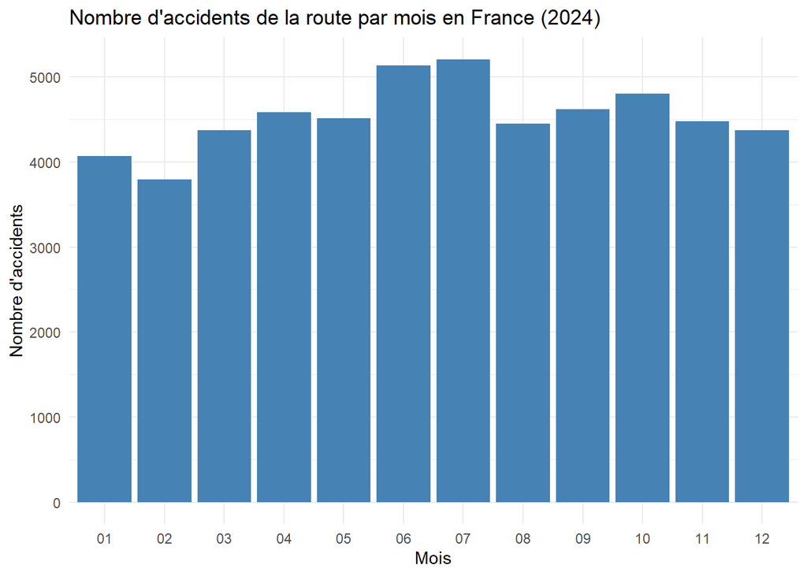

```r
ggplot(accidents_mois, aes(x = mois, y = nb_accidents)) +
  geom_col(fill = "steelblue") +
  labs(
    title = "Nombre d'accidents de la route par mois en France (2024)",
    x = "Mois",
    y = "Nombre d'accidents"
  ) +
  theme_minimal()
```

Analyse :juillet est le mois qui compte le plus d’accidents (5 209), tandis que février en compte le moins (3 792). il s’agit de nombres bruts d’accidents, pas d’une mesure du risque individuel.

### 4.2.1. Répartition horaire des accidents

```r
accidents_heure <- accidents |>
  count(heure, name = "nb_accidents") |>
  arrange(heure)

accidents_heure
```

```
## # A tibble: 24 × 2
##    heure nb_accidents
##    <int>        <int>
##  1     0         1168
##  2     1          955
##  3     2          807
##  4     3          602
##  5     4          630
##  6     5          886
##  7     6         1218
##  8     7         2442
##  9     8         3161
## 10     9         2673
## # ℹ 14 more rows
```

*Visualisation graphique des horaires*

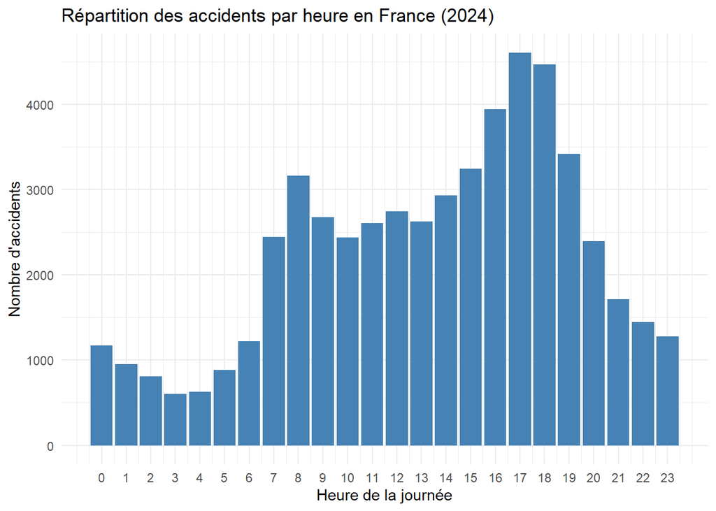

```r
ggplot(accidents_heure, aes(x = heure, y = nb_accidents)) +
  geom_col(fill = "steelblue") +
  scale_x_continuous(breaks = 0:23) +
  labs(
    title = "Répartition des accidents par heure en France (2024)",
    x = "Heure de la journée",
    y = "Nombre d'accidents"
  ) +
  theme_minimal()
```

Observations: 17h c’est l’heur ou il y’a le plus accidents avec 4607 3h l’heur le moins accidents avec 602 On observe également une augmentation importante entre 6 h et 8 h, puis un pic en fin d’après-midi, notamment à 17 h et 18 h.

!ces chiffres représentent les volumes d’accidents enregistrés, pas le risque d’accident par trajet ou par heure de circulation.

### 4.2.3. Répartition des accidents selon la période de la journée

Visualisation des quatres periodes

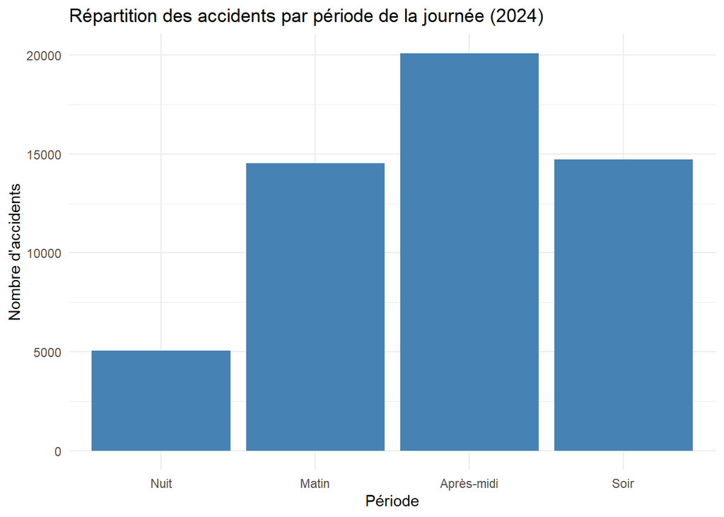

```r
accidents_periode <- accidents |>
  count(periode, name = "nb_accidents") |>
  mutate(
    periode = factor(
      periode,
      levels = c("Nuit", "Matin", "Après-midi", "Soir")
    )
  )

ggplot(accidents_periode,
       aes(x = periode, y = nb_accidents)) +
  geom_col(fill = "steelblue") +
  labs(
    title = "Répartition des accidents par période de la journée (2024)",
    x = "Période",
    y = "Nombre d'accidents"
  ) +
  theme_minimal()
```

**Observation** : l’après-midi concentre le plus grand nombre d’accidents dans notre jeu de données, avec environ 36,9 %. La nuit présente le plus faible effectif.

!ce sont des nombres d’accidents, pas des taux de risque rapportés au trafic.

## 4.3 Axe 2-Analyse géographique et environnementale

### 4.3.1.Répartition des accidents par departement

On va compter le nombre d’accident dans chaque département,puis identifier les 10 départements qui en enrégistre le plus

Objectifs : - Identifier les départements les plus touchés en nombre d’accidents. - Comparer leur poids dans l’ensemble des accidents. - Préparer une future carte interactive par département

```r
accidents_dep <- accidents |>
  count(dep, name = "nb_accidents") |>
  arrange(desc(nb_accidents))
```

**les 10 premier département**

```r
head(accidents_dep, 10)
```

```
## # A tibble: 10 × 2
##    dep   nb_accidents
##    <chr>        <int>
##  1 75            4191
##  2 93            2640
##  3 92            2485
##  4 13            2120
##  5 94            1963
##  6 69            1627
##  7 91            1348
##  8 33            1202
##  9 77            1068
## 10 59            1023
```

*Résultats sous forme de tableau*

```r
library(knitr)

dep <- data.frame(
  Rang = 1:10,
  Département = c("75 – Paris", "93 – Seine-Saint-Denis", "92 – Hauts-de-Seine",
                  "13 – Bouches-du-Rhône", "94 – Val-de-Marne", "69 – Rhône",
                  "91 – Essonne", "33 – Gironde", "77 – Seine-et-Marne",
                  "59 – Nord"),
  `Nombre d'accidents` = c(4191, 2640, 2485, 2120, 1963, 1627, 1348, 1202,
                           1068, 1023),
  check.names = FALSE
)

kable(dep, format.args = list(big.mark = " "),
      caption = "Classement des 10 premiers départements")
```

Classement des 10 premiers départements

| Rang | Département | Nombre d’accidents |
| --- | --- | --- |
| 1 | 75 – Paris | 4 191 |
| 2 | 93 – Seine-Saint-Denis | 2 640 |
| 3 | 92 – Hauts-de-Seine | 2 485 |
| 4 | 13 – Bouches-du-Rhône | 2 120 |
| 5 | 94 – Val-de-Marne | 1 963 |
| 6 | 69 – Rhône | 1 627 |
| 7 | 91 – Essonne | 1 348 |
| 8 | 33 – Gironde | 1 202 |
| 9 | 77 – Seine-et-Marne | 1 068 |
| 10 | 59 – Nord | 1 023 |

On vérifie le total

```r
sum(accidents_dep$nb_accidents)
```

```
## [1] 54402
```

C’est ok!

*Visualisation des 10 premiers départements*

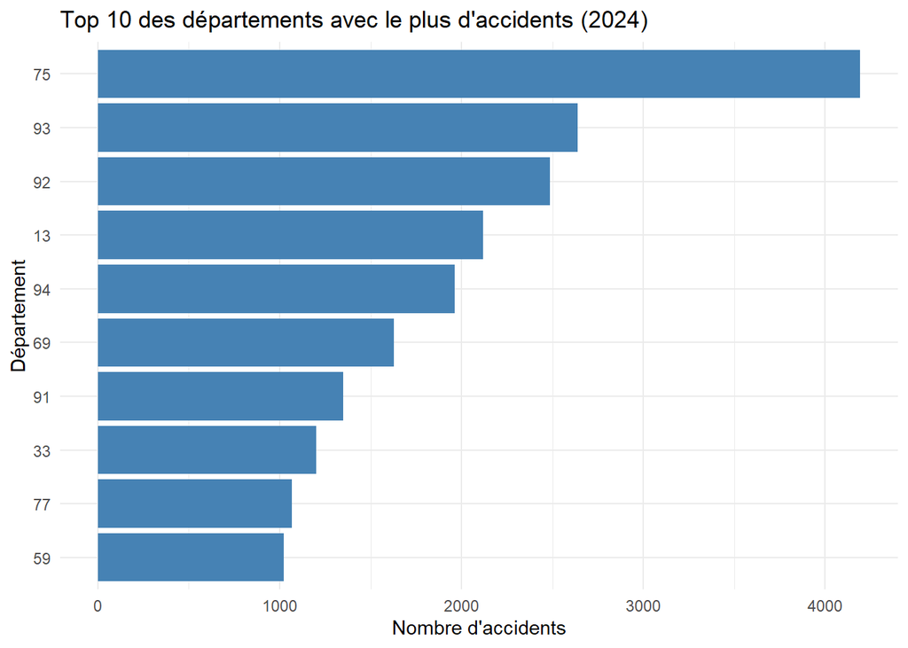

```r
accidents_dep_top10 <- accidents_dep |>
  slice_max(
    order_by = nb_accidents,
    n = 10,
    with_ties = FALSE
  ) |>
  mutate(
    dep = factor(dep, levels = rev(dep))
  )

ggplot(accidents_dep_top10,
       aes(x = dep, y = nb_accidents)) +
  geom_col(fill = "steelblue") +
  coord_flip() +
  labs(
    title = "Top 10 des départements avec le plus d'accidents (2024)",
    x = "Département",
    y = "Nombre d'accidents"
  ) +
  theme_minimal()
```

observation : Paris arrive largement en tête avec 4 191 accidents. L’Île-de-France est particulièrement représentée dans ce classement.

### 4.3.2. Répartition des accidents par commune:les 10 communes qui enrégistrent le plus des accidents

```r
accidents_com <- accidents |>
  count(dep, com, name = "nb_accidents") |>
  arrange(desc(nb_accidents))

head(accidents_com, 10)
```

```
## # A tibble: 10 × 3
##    dep   com   nb_accidents
##    <chr> <chr>        <int>
##  1 973   97302          479
##  2 75    75116          423
##  3 75    75117          339
##  4 75    75115          338
##  5 51    51454          308
##  6 75    75119          304
##  7 974   97411          304
##  8 75    75112          280
##  9 75    75120          274
## 10 44    44109          269
```

**observations** : - La commune 97302, en Guyane, arrive en tête avec 479 accidents. - Plusieurs arrondissements de Paris figurent dans le Top 10. - Les communes de Paris sont identifiées par des codes spécifiques, par exemple 75116 pour le 16ᵉ arrondissement. - Ces chiffres sont des volumes bruts : ils ne mesurent pas le risque individuel d’accident.

*Visualisation*

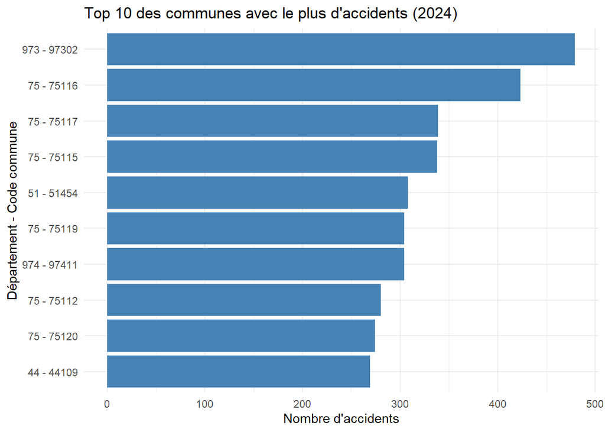

```r
accidents_com_top10 <- accidents_com |>
  slice_max(
    order_by = nb_accidents,
    n = 10,
    with_ties = FALSE
  ) |>
  mutate(
    commune = paste(dep, com, sep = " - "),
    commune = factor(commune, levels = rev(commune))
  )

ggplot(accidents_com_top10,
       aes(x = commune, y = nb_accidents)) +
  geom_col(fill = "steelblue") +
  coord_flip() +
  labs(
    title = "Top 10 des communes avec le plus d'accidents (2024)",
    x = "Département - Code commune",
    y = "Nombre d'accidents"
  ) +
  theme_minimal()
```

### 4.3.3.Répartition des accidents selon la localisation

Mesurer la répartition des accidents selon leur localisation

```r
accidents_agg <- accidents |>
  count(agg_libelle, name = "nb_accidents") |>
  mutate(
    pourcentage = round(
      nb_accidents / sum(nb_accidents) * 100, 2
    )
  ) |>
  arrange(desc(nb_accidents))

accidents_agg
```

```
## # A tibble: 2 × 3
##   agg_libelle        nb_accidents pourcentage
##   <chr>                     <int>       <dbl>
## 1 En agglomération          34010        62.5
## 2 Hors agglomération        20392        37.5
```

*Visualisation graphique*

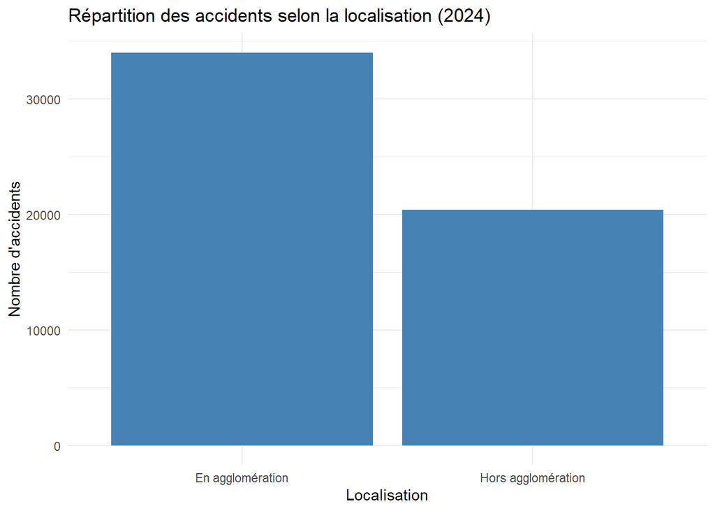

```r
ggplot(accidents_agg,
       aes(x = agg_libelle, y = nb_accidents)) +
  geom_col(fill = "steelblue") +
  labs(
    title = "Répartition des accidents selon la localisation (2024)",
    x = "Localisation",
    y = "Nombre d'accidents"
  ) +
  theme_minimal()
```

constat : près de 63 % des accidents recensés en 2024 ont eu lieu en agglomération, contre environ 37 % hors agglomération.

### 4.3.4 Répartition des accidents selon les conditions atmospheriques

Etudier l’influence des conditions météorologiques au moment des accidents (temps normal,pluie,neige,brouillard,vent,etc)

```r
accidents_atm <- accidents |>
  count(atm_libelle, name = "nb_accidents") |>
  mutate(
    pourcentage = round(
      nb_accidents / sum(nb_accidents) * 100, 2
    )
  ) |>
  arrange(desc(nb_accidents))

accidents_atm
```

```
## # A tibble: 9 × 3
##   atm_libelle         nb_accidents pourcentage
##   <chr>                      <int>       <dbl>
## 1 Normale                    41802       76.8
## 2 Pluie légère                6779       12.5
## 3 Temps couvert               2374        4.36
## 4 Pluie forte                 1449        2.66
## 5 Temps éblouissant            817        1.5
## 6 Brouillard - fumée           529        0.97
## 7 Autre                        250        0.46
## 8 Neige - grêle                233        0.43
## 9 Vent fort - tempête          169        0.31
```

```r
dim(accidents)
```

```
## [1] 54402    36
```

```r
n_distinct(accidents$Num_Acc)
```

```
## [1] 54402
```

```r
sum(duplicated(accidents$Num_Acc))
```

```
## [1] 0
```

*Restaurer la base propre*

```r
accidents <- readRDS("data/accidents_clean.rds")
```

```r
dim(accidents)
```

```
## [1] 54402    36
```

```r
n_distinct(accidents$Num_Acc)
```

```
## [1] 54402
```

```r
sum(duplicated(accidents$Num_Acc))
```

```
## [1] 0
```

```r
dim(carac)
```

```
## [1] 54402    15
```

```r
dim(grav_acc)
```

```
## [1] 54402     4
```

```r
dim(age_acc)
```

```
## [1] 54402     7
```

```r
dim(vehicules_acc)
```

```
## [1] 54402     2
```

ok! les quatres tables sources sont correctes.

*Reconstruction de la table accidents*

```r
accidents <- carac |>
  left_join(grav_acc, by = "Num_Acc") |>
  left_join(age_acc, by = "Num_Acc") |>
  left_join(vehicules_acc, by = "Num_Acc")
```

```r
dim(accidents)
```

```
## [1] 54402    25
```

```r
n_distinct(accidents$Num_Acc)
```

```
## [1] 54402
```

```r
sum(duplicated(accidents$Num_Acc))
```

```
## [1] 0
```

```r
colSums(is.na(accidents))
```

```
##           Num_Acc              jour              mois                an
##                 0                 0                 0                 0
##              hrmn               lum               dep               com
##                 0                 0                 0                 0
##               agg               int               atm               col
##                 0                 0                 0                 0
##               adr               lat              long        nb_usagers
##                 2                 0                 0                 0
##             grave               tue        nb_Adultes nb_Jeunes adultes
##                 0                 0                 0                 0
##        nb_Seniors    nb_Adolescents   nb_Adultes mûrs        nb_Enfants
##                 0                 0                 0                 0
##      nb_vehicules
##                 0
```

parfait!

*Recréer les variables temporelle, les libellés et les coordonnées*

```r
library(lubridate)

accidents <- accidents |>
  mutate(
    date = make_date(
      year = an,
      month = as.integer(mois),
      day = jour
    ),
    heure = hour(hrmn),
    minute = minute(hrmn),

    periode = case_when(
      heure >= 0 & heure < 6 ~ "Nuit",
      heure >= 6 & heure < 12 ~ "Matin",
      heure >= 12 & heure < 18 ~ "Après-midi",
      heure >= 18 & heure < 24 ~ "Soir"
    ),

    lum_libelle = case_when(
      lum == 1 ~ "Plein jour",
      lum == 2 ~ "Crépuscule ou aube",
      lum == 3 ~ "Nuit sans éclairage public",
      lum == 4 ~ "Nuit avec éclairage public non allumé",
      lum == 5 ~ "Nuit avec éclairage public allumé"
    ),

    agg_libelle = case_when(
      agg == 1 ~ "Hors agglomération",
      agg == 2 ~ "En agglomération"
    ),

    int_libelle = case_when(
      int == 1 ~ "Hors intersection",
      int == 2 ~ "Intersection en X",
      int == 3 ~ "Intersection en T",
      int == 4 ~ "Intersection en Y",
      int == 5 ~ "Intersection à plus de 4 branches",
      int == 6 ~ "Giratoire",
      int == 7 ~ "Place",
      int == 8 ~ "Passage à niveau",
      int == 9 ~ "Autre intersection"
    ),

    atm_libelle = case_when(
      atm == 1 ~ "Normale",
      atm == 2 ~ "Pluie légère",
      atm == 3 ~ "Pluie forte",
      atm == 4 ~ "Neige - grêle",
      atm == 5 ~ "Brouillard - fumée",
      atm == 6 ~ "Vent fort - tempête",
      atm == 7 ~ "Temps éblouissant",
      atm == 8 ~ "Temps couvert",
      atm == 9 ~ "Autre"
    ),

    col_libelle = case_when(
      trimws(col) == "1" ~ "Deux véhicules - frontale",
      trimws(col) == "2" ~ "Deux véhicules - arrière",
      trimws(col) == "3" ~ "Deux véhicules - côté",
      trimws(col) == "4" ~ "Trois véhicules et plus - en chaîne",
      trimws(col) == "5" ~ "Trois véhicules et plus - collisions multiples",
      trimws(col) == "6" ~ "Autre collision",
      trimws(col) == "7" ~ "Sans collision",
      trimws(col) == "-1" ~ "Non renseigné"
    ),

    latitude = as.numeric(gsub(",", ".", trimws(lat))),
    longitude = as.numeric(gsub(",", ".", trimws(long)))
  )
```

```r
dim(accidents)
```

```
## [1] 54402    36
```

```r
n_distinct(accidents$Num_Acc)
```

```
## [1] 54402
```

```r
sum(duplicated(accidents$Num_Acc))
```

```
## [1] 0
```

super!

*Recalcul de la répartition météorologique*

```r
accidents_atm <- accidents |>
  count(atm_libelle, name = "nb_accidents") |>
  mutate(
    pourcentage = round(
      nb_accidents / sum(nb_accidents) * 100, 2
    )
  ) |>
  arrange(desc(nb_accidents))

accidents_atm
```

```
## # A tibble: 9 × 3
##   atm_libelle         nb_accidents pourcentage
##   <chr>                      <int>       <dbl>
## 1 Normale                    41802       76.8
## 2 Pluie légère                6779       12.5
## 3 Temps couvert               2374        4.36
## 4 Pluie forte                 1449        2.66
## 5 Temps éblouissant            817        1.5
## 6 Brouillard - fumée           529        0.97
## 7 Autre                        250        0.46
## 8 Neige - grêle                233        0.43
## 9 Vent fort - tempête          169        0.31
```

constat : 76,84 % des accidents ont eu lieu lorsque les conditions atmosphériques étaient normales. La pluie légère arrive en deuxième position avec 12,46 %.

*Visualisation graphique*

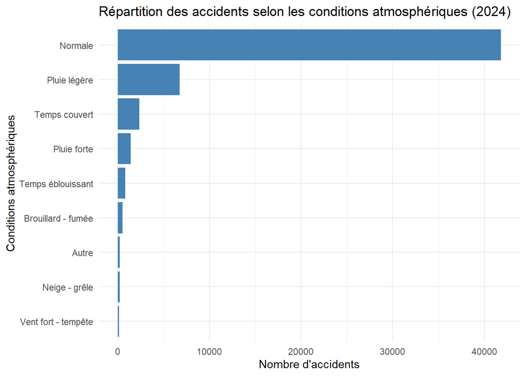

```r
ggplot(accidents_atm,
       aes(x = reorder(atm_libelle, nb_accidents),
           y = nb_accidents)) +
  geom_col(fill = "steelblue") +
  coord_flip() +
  labs(
    title = "Répartition des accidents selon les conditions atmosphériques (2024)",
    x = "Conditions atmosphériques",
    y = "Nombre d'accidents"
  ) +
  theme_minimal()
```

### 4.3.5.Répartition des accidents selon l’état de la surface de la chaussée

Etudier les accidents qui se produisent davantage sur une chaussée :sèche,mouillée , enneigée, verglacée,etc

```r
table(lieux$surf, useNA = "ifany")
```

```
##
##    -1     1     2     3     4     5     6     7     8     9
##    38 54953 14257   125    43   120    63   268    85   296
```

ces effectifs représentent des enrégistrement de lieux.

*Corespondance officiel des codes*

```r
library(knitr)

surf <- data.frame(
  Code = c("1", "2", "3", "4", "5", "6", "7", "8", "9", "-1"),
  `État de la chaussée` = c("Normale (sèche)", "Mouillée", "Présence de flaques",
                            "Inondée", "Enneigée", "Boue", "Verglacée",
                            "Corps gras - huile", "Autre", "Non renseigné"),
  check.names = FALSE
)

kable(surf, caption = "Correspondance officielle des codes : état de la chaussée (surf)")
```

Correspondance officielle des codes : état de la chaussée (surf)

| Code | État de la chaussée |
| --- | --- |
| 1 | Normale (sèche) |
| 2 | Mouillée |
| 3 | Présence de flaques |
| 4 | Inondée |
| 5 | Enneigée |
| 6 | Boue |
| 7 | Verglacée |
| 8 | Corps gras - huile |
| 9 | Autre |
| -1 | Non renseigné |

*Créer la variable surf_libelle*

```r
lieux <- lieux |>
  mutate(
    surf_libelle = case_when(
      trimws(as.character(surf)) == "1" ~ "Normale",
      trimws(as.character(surf)) == "2" ~ "Mouillée",
      trimws(as.character(surf)) == "3" ~ "Flaques",
      trimws(as.character(surf)) == "4" ~ "Inondée",
      trimws(as.character(surf)) == "5" ~ "Enneigée",
      trimws(as.character(surf)) == "6" ~ "Boue",
      trimws(as.character(surf)) == "7" ~ "Verglacée",
      trimws(as.character(surf)) == "8" ~ "Corps gras - huile",
      trimws(as.character(surf)) == "9" ~ "Autre",
      trimws(as.character(surf)) == "-1" ~ "Non renseigné",
      TRUE ~ "Code non documenté"
    )
  )
```

```r
table(lieux$surf, lieux$surf_libelle)
```

```
##
##       Autre  Boue Corps gras - huile Enneigée Flaques Inondée Mouillée
##    -1     0     0                  0        0       0       0        0
##   1       0     0                  0        0       0       0        0
##   2       0     0                  0        0       0       0    14257
##   3       0     0                  0        0     125       0        0
##   4       0     0                  0        0       0      43        0
##   5       0     0                  0      120       0       0        0
##   6       0    63                  0        0       0       0        0
##   7       0     0                  0        0       0       0        0
##   8       0     0                 85        0       0       0        0
##   9     296     0                  0        0       0       0        0
##
##       Non renseigné Normale Verglacée
##    -1            38       0         0
##   1               0   54953         0
##   2               0       0         0
##   3               0       0         0
##   4               0       0         0
##   5               0       0         0
##   6               0       0         0
##   7               0       0       268
##   8               0       0         0
##   9               0       0         0
```

*compptage*

```r
lieux_surf_acc <- lieux |>
  distinct(Num_Acc, surf_libelle) |>
  count(surf_libelle, name = "nb_accidents") |>
  mutate(pourcentage = round(nb_accidents / n_distinct(lieux$Num_Acc) * 100, 2)) |>
  arrange(desc(nb_accidents))

lieux_surf_acc
```

```
## # A tibble: 10 × 3
##    surf_libelle       nb_accidents pourcentage
##    <chr>                     <int>       <dbl>
##  1 Normale                   42497       78.1
##  2 Mouillée                  11155       20.5
##  3 Autre                       279        0.51
##  4 Verglacée                   232        0.43
##  5 Flaques                     104        0.19
##  6 Enneigée                    103        0.19
##  7 Corps gras - huile           81        0.15
##  8 Boue                         61        0.11
##  9 Inondée                      40        0.07
## 10 Non renseigné                38        0.07
```

```r
sum(lieux_surf_acc$nb_accidents)
```

```
## [1] 54590
```

Un même accident peut avoir plusieurs enregistrements dans la table lieux, avec des états de chaussée différents: il peut donc apparaître dans plusieurs catégories. Le total (54 590) dépasse le nombre d’accidents (54 402) et les pourcentages ne s’additionnent pas à 100 %.

**Remarque** : - 78,12 % des accidents sont associés à une chaussée normale. - 20,50 % sont associés à une chaussée mouillée. - Les autres états représentent des proportions beaucoup plus faibles.

**Attention**: le total des effectifs est de 54 590, supérieur à 54 402. C’est normal ici : un même accident peut être associé à plusieurs états de chaussée. Les pourcentages ne sont donc pas exclusifs.

*Visualisation graphique*

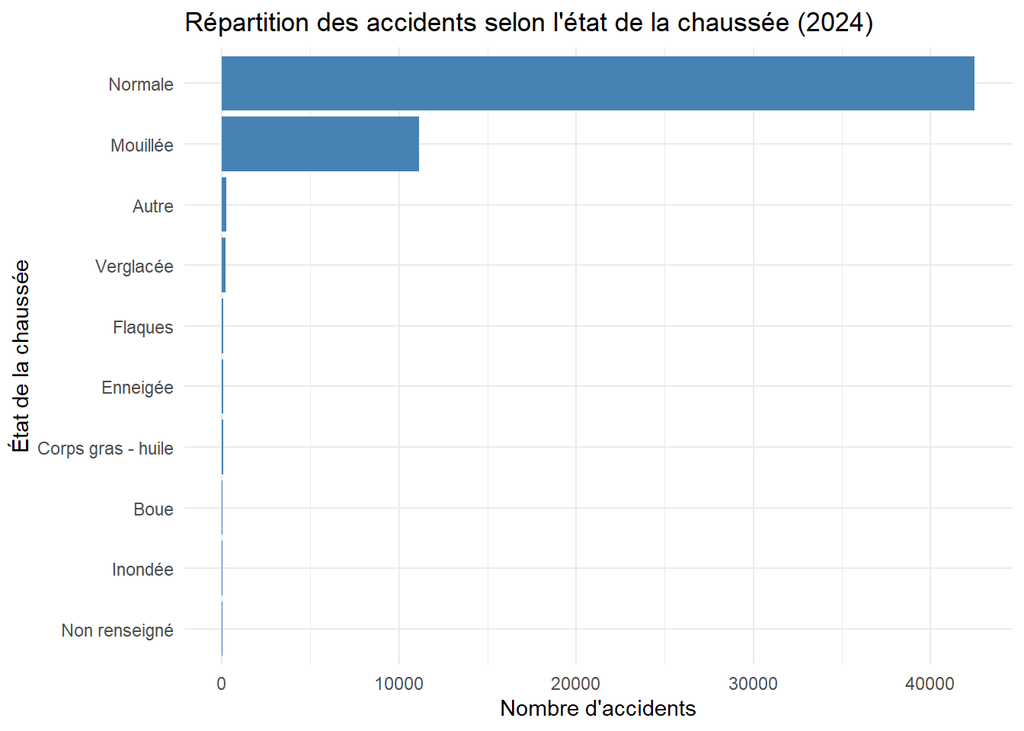

```r
ggplot(lieux_surf_acc,
       aes(x = reorder(surf_libelle, nb_accidents),
           y = nb_accidents)) +
  geom_col(fill = "steelblue") +
  coord_flip() +
  labs(
    title = "Répartition des accidents selon l'état de la chaussée (2024)",
    x = "État de la chaussée",
    y = "Nombre d'accidents"
  ) +
  theme_minimal()
```

### 4.3.6.Répartition des accidents semon le type d’intersection

```r
accidents_intersection <- accidents |>
  count(int_libelle, name = "nb_accidents") |>
  mutate(
    pourcentage = round(
      nb_accidents / sum(nb_accidents) * 100, 2
    )
  ) |>
  arrange(desc(nb_accidents))

accidents_intersection
```

```
## # A tibble: 9 × 3
##   int_libelle                       nb_accidents pourcentage
##   <chr>                                    <int>       <dbl>
## 1 Hors intersection                        34589       63.6
## 2 Intersection en T                         6451       11.9
## 3 Intersection en X                         6289       11.6
## 4 Giratoire                                 2717        4.99
## 5 Autre intersection                        2454        4.51
## 6 Intersection en Y                         1048        1.93
## 7 Place                                      453        0.83
## 8 Intersection à plus de 4 branches          263        0.48
## 9 Passage à niveau                           138        0.25
```

```r
sum(accidents_intersection$nb_accidents)
```

```
## [1] 54402
```

**constats**:63,58 % des accidents ont lieu hors intersection. Les intersections en T et en X représentent respectivement 11,86 % et 11,56 %. Les giratoires représentent près de 5 % des accidents.

*Visualisation graphique*

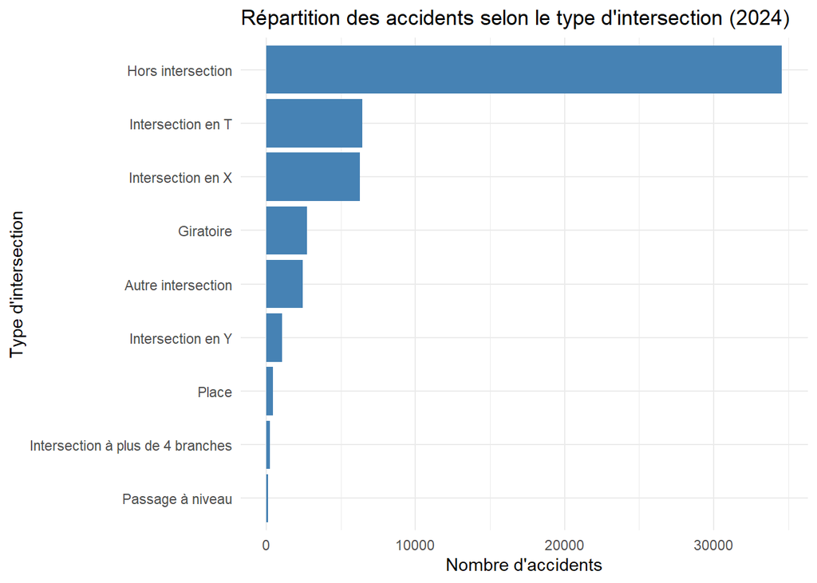

```r
ggplot(accidents_intersection,
       aes(x = reorder(int_libelle, nb_accidents),
           y = nb_accidents)) +
  geom_col(fill = "steelblue") +
  coord_flip() +
  labs(
    title = "Répartition des accidents selon le type d'intersection (2024)",
    x = "Type d'intersection",
    y = "Nombre d'accidents"
  ) +
  theme_minimal()
```

### 4.3.7.Synthèse de l’axe 2: analyse géographique et environnementale

On a réalisé les analyses suivantes :

1. Répartition des accidents par département.
2. Top 10 des communes les plus accidentogènes en nombre d’accidents.
3. Accidents en agglomération et hors agglomération.
4. Conditions atmosphériques.
5. État de la chaussée.
6. Type d’intersection.

### 4.4.Axe 3: Analyse des profils des usagers

On va étudier maintenant les personnes impliquées dans les accidents : age,sexe,gravité des blessures et catégories d’usagers.

### 4.4.1.Répartition des usagers selon le sexe

```r
usagers <- usagers |>
  mutate(sexe = as.integer(trimws(as.character(sexe))))

table(usagers$sexe, useNA = "ifany")
```

```
##
##    -1     1     2
##  2395 83864 38928
```

```r
usagers_sexe <- usagers |>
  count(sexe, name = "nb_usagers") |>
  mutate(
    pourcentage = round(
      nb_usagers / sum(nb_usagers) * 100, 2
    )
  ) |>
  arrange(desc(nb_usagers))

usagers_sexe
```

```
## # A tibble: 3 × 3
##    sexe nb_usagers pourcentage
##   <int>      <int>       <dbl>
## 1     1      83864       67.0
## 2     2      38928       31.1
## 3    -1       2395        1.91
```

On a la répartition des 125187 usagers impliqués dans les accidents de la route en France (2024) Interprétation: Dans la nomenclature BAAC : - Code 1 : Homme - Code 2 : Femme - Code -1 : Non renseigné

constat : les hommes représentent environ deux tiers des usagers impliqués dans les accidents recensés.

*Visualisation graphique*

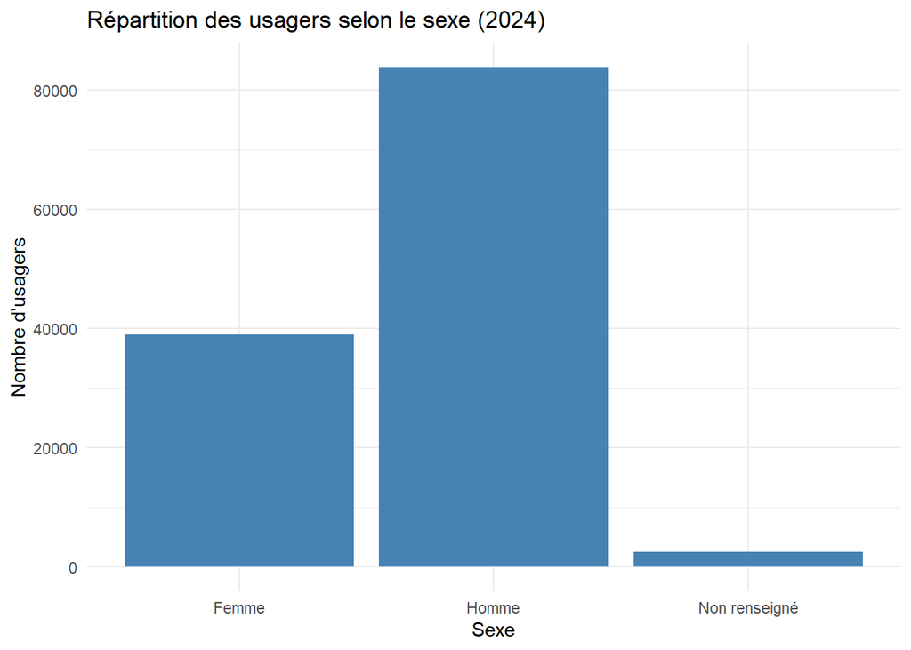

```r
usagers_sexe_graph <- usagers_sexe |>
  mutate(
    sexe_libelle = case_when(
      sexe == "1" ~ "Homme",
      sexe == "2" ~ "Femme",
      sexe == "-1" ~ "Non renseigné"
    )
  )

ggplot(usagers_sexe_graph,
       aes(x = sexe_libelle, y = nb_usagers)) +
  geom_col(fill = "steelblue") +
  labs(
    title = "Répartition des usagers selon le sexe (2024)",
    x = "Sexe",
    y = "Nombre d'usagers"
  ) +
  theme_minimal()
```

### 4.4.2. Analyse des usagrs selon l’age

On va étudier les classes d’âge des personnes impliquées dans les accidents. On avait déjà créé la variable classe_age dans la table usagers. on va donc la réutiliser, sans refaire le calcul des âges.

```r
usagers_age <- usagers |>
  count(classe_age, name = "nb_usagers") |>
  mutate(
    pourcentage = round(
      nb_usagers / sum(nb_usagers) * 100, 2
    )
  ) |>
  arrange(desc(nb_usagers))

usagers_age
```

```
## # A tibble: 7 × 3
##   classe_age     nb_usagers pourcentage
##   <chr>               <int>       <dbl>
## 1 Adultes             43745       34.9
## 2 Adultes mûrs        29729       23.8
## 3 Jeunes adultes      23366       18.7
## 4 Seniors             14321       11.4
## 5 Enfants              6657        5.32
## 6 Adolescents          4790        3.83
## 7 <NA>                 2579        2.06
```

constats : - Les adultes de 25 à 44 ans constituent la catégorie la plus représentée (34,94 %). - Les adultes de 25 à 64 ans représentent ensemble 58,69 % des usagers. - Les jeunes adultes de 18 à 24 ans représentent 18,66 %.

*Visualisation graphique*

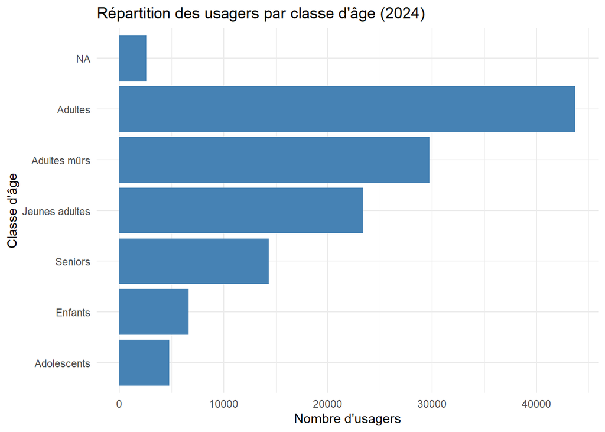

```r
ggplot(usagers_age,
       aes(x = reorder(classe_age, nb_usagers),
           y = nb_usagers)) +
  geom_col(fill = "steelblue") +
  coord_flip() +
  labs(
    title = "Répartition des usagers par classe d'âge (2024)",
    x = "Classe d'âge",
    y = "Nombre d'usagers"
  ) +
  theme_minimal()
```

### 4.4.3. Analyse de la gravité

```r
usagers_gravite <- usagers |>
  count(grav, name = "nb_usagers") |>
  mutate(
    pourcentage = round(
      nb_usagers / sum(nb_usagers) * 100, 2
    )
  ) |>
  arrange(grav)

usagers_gravite
```

```
## # A tibble: 4 × 3
##    grav nb_usagers pourcentage
##   <dbl>      <int>       <dbl>
## 1     1      52920       42.3
## 2     2       3432        2.74
## 3     3      19126       15.3
## 4     4      49709       39.7
```

On a les quatres catégories de gravité pour les 125187 usagers

Signification des codes Selon la nomenclature BAAC : Code Signification 1 Indemne 2 Tué 3 Blessé hospitalisé 4 Blessé léger

Constats importants : - 42,27 % des usagers sont indemnes. - 57,73 % ont été blessés ou tués. - 18,02 % des usagers sont tués ou blessés hospitalisés.

*Visualisation graphique*

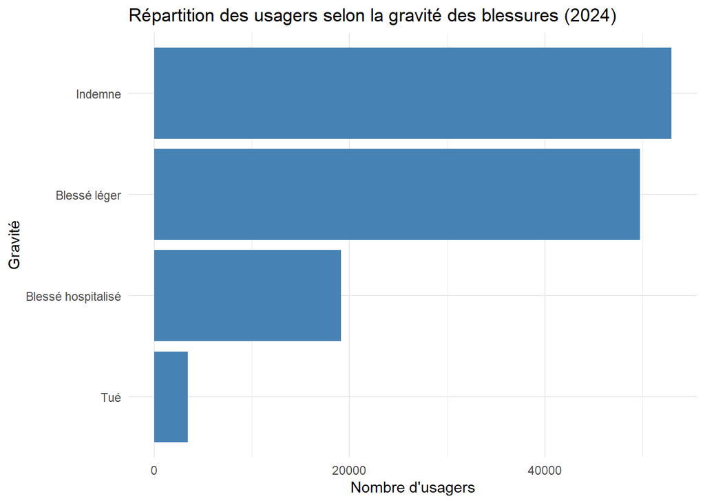

```r
usagers_gravite_graph <- usagers_gravite |>
  mutate(
    grav_libelle = case_when(
      grav == 1 ~ "Indemne",
      grav == 2 ~ "Tué",
      grav == 3 ~ "Blessé hospitalisé",
      grav == 4 ~ "Blessé léger"
    )
  )

ggplot(usagers_gravite_graph,
       aes(x = reorder(grav_libelle, nb_usagers),
           y = nb_usagers)) +
  geom_col(fill = "steelblue") +
  coord_flip() +
  labs(
    title = "Répartition des usagers selon la gravité des blessures (2024)",
    x = "Gravité",
    y = "Nombre d'usagers"
  ) +
  theme_minimal()
```

```r
data.frame(
  Indicateur = c("Accidents mortels (au moins un usager tué)", "Usagers tués"),
  Valeur = c(sum(accidents$tue), sum(usagers$grav == 2, na.rm = TRUE))
)
```

```
##                                   Indicateur Valeur
## 1 Accidents mortels (au moins un usager tué)   3226
## 2                               Usagers tués   3432
```

Un accident mortel compte au moins un usager tué : 3 226 accidents. Un même accident pouvant faire plusieurs victimes, le nombre d’usagers tués (3 432) est plus élevé. Le tableau de bord affiche le nombre d’accidents mortels.

### 4.4.4. Analyse des catégories d’usagers

```r
table(usagers$catu, useNA = "ifany")
```

```
##
##     1     2     3
## 92581 23205  9401
```

On a trois catégories d’usagers pour 125187 personnes

Signification des codes BAAC Code Catégorie 1 Conducteur 2 Passager 3 Piéton

*Tableau de répartition*

```r
usagers_catu <- usagers |>
  mutate(
    catu_libelle = case_when(
      catu == 1 ~ "Conducteur",
      catu == 2 ~ "Passager",
      catu == 3 ~ "Piéton"
    )
  ) |>
  count(catu_libelle, name = "nb_usagers") |>
  mutate(
    pourcentage = round(
      nb_usagers / sum(nb_usagers) * 100, 2
    )
  ) |>
  arrange(desc(nb_usagers))

usagers_catu
```

```
## # A tibble: 3 × 3
##   catu_libelle nb_usagers pourcentage
##   <chr>             <int>       <dbl>
## 1 Conducteur        92581       74.0
## 2 Passager          23205       18.5
## 3 Piéton             9401        7.51
```

Constat principal : près de 74 % des personnes impliquées dans les accidents sont des conducteurs. Les passagers représentent 18,54 % et les piétons 7,51 %.

*Visualisation graphique*

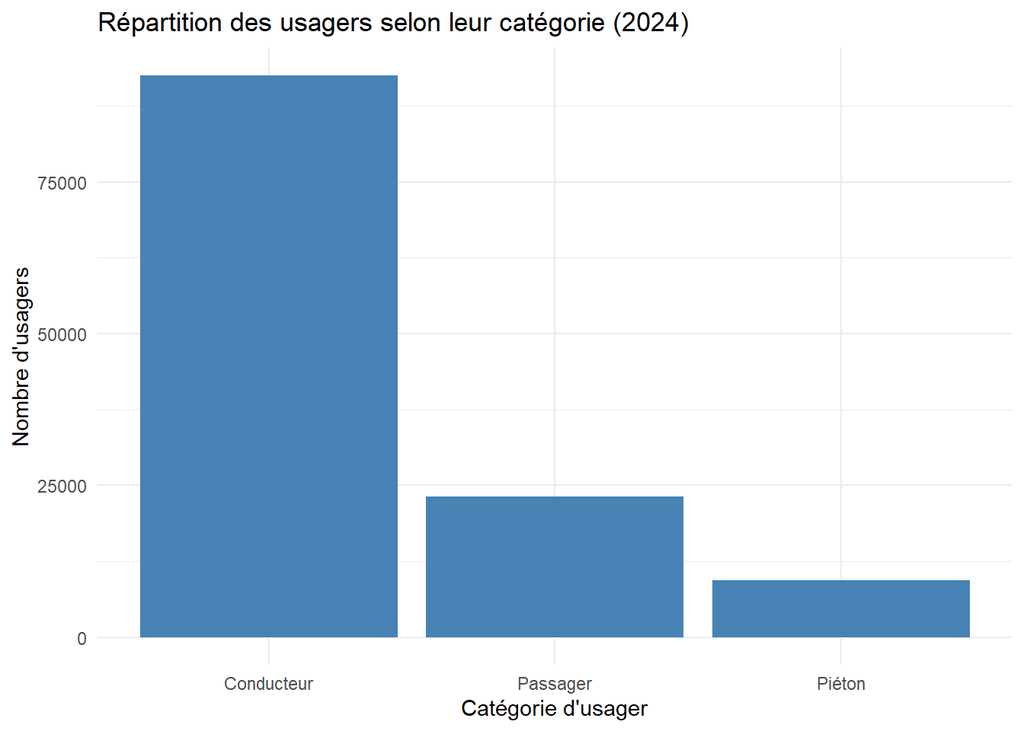

```r
ggplot(usagers_catu,
       aes(x = catu_libelle, y = nb_usagers)) +
  geom_col(fill = "steelblue") +
  labs(
    title = "Répartition des usagers selon leur catégorie (2024)",
    x = "Catégorie d'usager",
    y = "Nombre d'usagers"
  ) +
  theme_minimal()
```

On va approfondir l’analyse en commençant par la gravité des blessures selon l’âge. L’objectif est de comparer, pour chaque tranche d’âge, la proportion d’usagers indemnes, tués, blessés hospitalisés et blessés légers.

### 4.4.5.Préparation des libellés de gravité

```r
usagers <- usagers |>
  mutate(
    grav_libelle = case_when(
      grav == 1 ~ "Indemne",
      grav == 2 ~ "Tué",
      grav == 3 ~ "Blessé hospitalisé",
      grav == 4 ~ "Blessé léger",
      TRUE ~ "Non renseigné"
    )
  )
```

```r
table(usagers$grav_libelle, useNA = "ifany")
```

```
##
## Blessé hospitalisé       Blessé léger            Indemne                Tué
##              19126              49709              52920               3432
```

*Gravité selon la tranche d’age*

```r
gravite_age <- usagers |>
  filter(!is.na(classe_age)) |>
  count(classe_age, grav_libelle, name = "nb_usagers") |>
  group_by(classe_age) |>
  mutate(
    pourcentage = round(
      nb_usagers / sum(nb_usagers) * 100, 2
    )
  ) |>
  ungroup() |>
  arrange(classe_age, grav_libelle)
```

```r
gravite_age
```

```
## # A tibble: 24 × 4
##    classe_age   grav_libelle       nb_usagers pourcentage
##    <chr>        <chr>                   <int>       <dbl>
##  1 Adolescents  Blessé hospitalisé       1162       24.3
##  2 Adolescents  Blessé léger             2592       54.1
##  3 Adolescents  Indemne                   960       20.0
##  4 Adolescents  Tué                        76        1.59
##  5 Adultes      Blessé hospitalisé       5536       12.7
##  6 Adultes      Blessé léger            17958       41.0
##  7 Adultes      Indemne                 19301       44.1
##  8 Adultes      Tué                       950        2.17
##  9 Adultes mûrs Blessé hospitalisé       4542       15.3
## 10 Adultes mûrs Blessé léger            10772       36.2
## # ℹ 14 more rows
```

*Visualisation graphique*

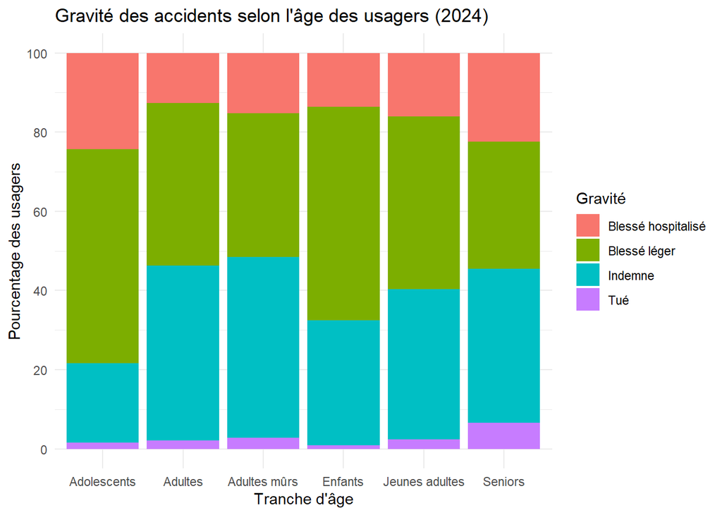

```r
ggplot(gravite_age,
       aes(x = classe_age,
           y = pourcentage,
           fill = grav_libelle)) +
  geom_col() +
  labs(
    title = "Gravité des accidents selon l'âge des usagers (2024)",
    x = "Tranche d'âge",
    y = "Pourcentage des usagers",
    fill = "Gravité"
  ) +
  scale_y_continuous(
    breaks = seq(0, 100, 20)
  ) +
  coord_cartesian(ylim = c(0, 100)) +
  theme_minimal()
```

*Calcul des proportions par sexe*

```r
gravite_sexe <- usagers |>
  filter(sexe %in% c("1", "2")) |>
  mutate(
    sexe_libelle = case_when(
      sexe == "1" ~ "Hommes",
      sexe == "2" ~ "Femmes"
    )
  ) |>
  count(sexe_libelle, grav_libelle, name = "nb_usagers") |>
  group_by(sexe_libelle) |>
  mutate(
    pourcentage = round(
      nb_usagers / sum(nb_usagers) * 100, 2
    )
  ) |>
  ungroup()

gravite_sexe
```

```
## # A tibble: 8 × 4
##   sexe_libelle grav_libelle       nb_usagers pourcentage
##   <chr>        <chr>                   <int>       <dbl>
## 1 Femmes       Blessé hospitalisé       5438       14.0
## 2 Femmes       Blessé léger            18323       47.1
## 3 Femmes       Indemne                 14398       37.0
## 4 Femmes       Tué                       769        1.98
## 5 Hommes       Blessé hospitalisé      13688       16.3
## 6 Hommes       Blessé léger            31386       37.4
## 7 Hommes       Indemne                 36127       43.1
## 8 Hommes       Tué                      2663        3.18
```

**Interprétation des résultats**

Quelques observations intéressantes : - Hommes : 3,18 % sont décédés, contre 1,98 % chez les femmes. - Hommes : 16,32 % sont blessés hospitalisés, contre 13,97 % chez les femmes. - Femmes : 47,07 % sont blessées légèrement, contre 37,42 % chez les hommes. - Hommes : 43,08 % sont indemnes, contre 36,99 % chez les femmes.

*Visualisation graphique*

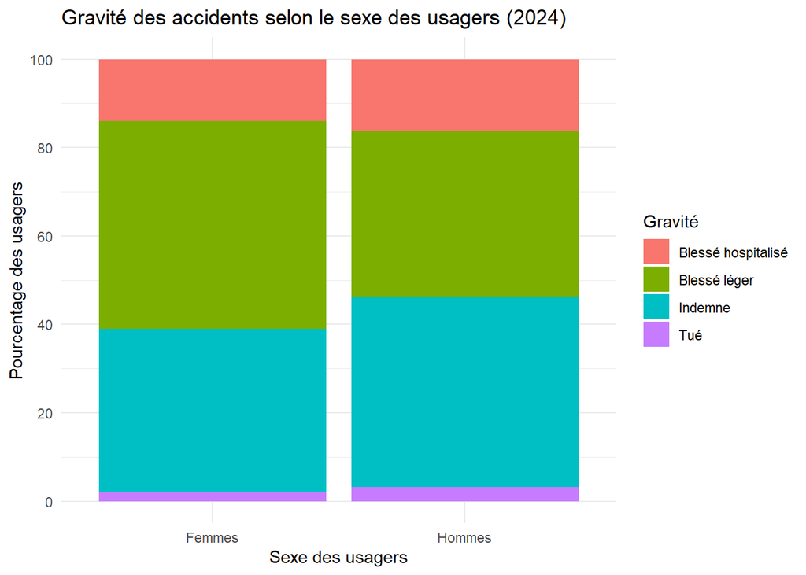

```r
ggplot(gravite_sexe,
       aes(x = sexe_libelle,
           y = pourcentage,
           fill = grav_libelle)) +
  geom_col() +
  labs(
    title = "Gravité des accidents selon le sexe des usagers (2024)",
    x = "Sexe des usagers",
    y = "Pourcentage des usagers",
    fill = "Gravité"
  ) +
  scale_y_continuous(
    breaks = seq(0, 100, 20)
  ) +
  coord_cartesian(ylim = c(0, 100)) +
  theme_minimal()
```

### 4.4.6.Synthèse de l’axe 3: On a réalisé six analyses : Analyse Résultat principal Sexe 66,99 % d’hommes Âge 34,94 % d’adultes (25–44 ans) Gravité 42,27 % d’usagers indemnes Catégorie 73,95 % de conducteurs Gravité selon l’âge 6,61 % de décès chez les seniors Gravité selon le sexe 3,18 % de décès chez les hommes, contre 1,98 % chez les femmes

On a également créé les tableaux et graphiques correspondants.

### 4.5.Axe 4: Analyse des véhicules

On étudie : 1. La répartition des véhicules selon leur catégorie (catv). 2. Le nombre de véhicules impliqués par accident. 3. Les types de véhicules les plus représentés. 4. La gravité des accidents selon la catégorie du véhicule, si les données le permettent.

### 4.5.1.Répartition des véhicules selon leur catégorie

```r
table(vehicules$catv, useNA = "ifany")
```

```
##
##    -1     0     1    10    13    14    15    16    17     2    20    21     3
##     1   287  5045  7062   380   652   936    28   493  3090    47   270   473
##    30    31    32    33    34    35    36    37    38    39    40    41    42
##  2036  1609  1714  7777   789    12   165   708   241    31   124    19    17
##    43    50    60     7    80    99
##   559  2867   255 53911   781   299
```

*Code Signification* 1 Bicyclette 2 Cyclomoteur 3 Voiturette 7 Véhicule de tourisme 10 Véhicule utilitaire 13, 14, 15 Poids lourds 16, 17 Tracteurs routiers 20 Engin spécial 21 Tracteur agricole 30 à 36 Scooters, motos et quads 37, 38 Autobus et autocars 39, 40 Train et tramway 41 à 43 Trois-roues motorisés 50 EDP à moteur 60 EDP sans moteur 80 Vélo à assistance électrique 99 Autre véhicule 0 Véhicule indéterminable -1 Non renseigné

observation : la catégorie 7 (véhicules de tourisme) domine largement avec 53 911 véhicules, soit environ 58,18 % du total.

Avant de créer le graphique, on va transformer les codes numériques catv en libellés compréhensibles. La nomenclature officielle de l’ONISR distingue notamment les voitures, les utilitaires, les poids lourds, les deux-roues et les transports collectifs.

*Création des libellés*

```r
vehicules <- vehicules |>
  mutate(
    catv_libelle = case_when(
      catv == -1 ~ "Non renseigné",
      catv == 0 ~ "Indéterminable",
      catv == 1 ~ "Bicyclette",
      catv == 2 ~ "Cyclomoteur",
      catv == 3 ~ "Voiturette",
      catv == 7 ~ "Véhicule de tourisme",
      catv == 10 ~ "Véhicule utilitaire",
      catv == 13 ~ "Poids lourd (3,5 à 7,5 t)",
      catv == 14 ~ "Poids lourd (> 7,5 t)",
      catv == 15 ~ "Poids lourd avec remorque",
      catv == 16 ~ "Tracteur routier seul",
      catv == 17 ~ "Tracteur routier avec semi-remorque",
      catv == 20 ~ "Engin spécial",
      catv == 21 ~ "Tracteur agricole",
      catv == 30 ~ "Scooter ≤ 50 cm³",
      catv == 31 ~ "Motocyclette 50–125 cm³",
      catv == 32 ~ "Scooter 50–125 cm³",
      catv == 33 ~ "Motocyclette > 125 cm³",
      catv == 34 ~ "Scooter > 125 cm³",
      catv == 35 ~ "Quad ≤ 50 cm³",
      catv == 36 ~ "Quad > 50 cm³",
      catv == 37 ~ "Autobus",
      catv == 38 ~ "Autocar",
      catv == 39 ~ "Train",
      catv == 40 ~ "Tramway",
      catv == 41 ~ "Trois-roues ≤ 50 cm³",
      catv == 42 ~ "Trois-roues 50–125 cm³",
      catv == 43 ~ "Trois-roues > 125 cm³",
      catv == 50 ~ "EDP à moteur",
      catv == 60 ~ "EDP sans moteur",
      catv == 80 ~ "Vélo à assistance électrique",
      catv == 99 ~ "Autre véhicule",
      TRUE ~ "Autre code"
    )
  )
```

```r
table(vehicules$catv_libelle)
```

```
##
##                             Autobus                             Autocar
##                                 708                                 241
##                          Autre code                      Autre véhicule
##                                   1                                 299
##                          Bicyclette                         Cyclomoteur
##                                5045                                3090
##                        EDP à moteur                     EDP sans moteur
##                                2867                                 255
##                       Engin spécial                      Indéterminable
##                                  47                                 287
##              Motocyclette > 125 cm³             Motocyclette 50–125 cm³
##                                7777                                1609
##               Poids lourd (> 7,5 t)           Poids lourd (3,5 à 7,5 t)
##                                 652                                 380
##           Poids lourd avec remorque                       Quad > 50 cm³
##                                 936                                 165
##                       Quad ≤ 50 cm³                   Scooter > 125 cm³
##                                  12                                 789
##                    Scooter ≤ 50 cm³                  Scooter 50–125 cm³
##                                2036                                1714
##                   Tracteur agricole Tracteur routier avec semi-remorque
##                                 270                                 493
##               Tracteur routier seul                               Train
##                                  28                                  31
##                             Tramway               Trois-roues > 125 cm³
##                                 124                                 559
##                Trois-roues ≤ 50 cm³              Trois-roues 50–125 cm³
##                                  19                                  17
##                Véhicule de tourisme                 Véhicule utilitaire
##                               53911                                7062
##        Vélo à assistance électrique                          Voiturette
##                                 781                                 473
```

*Verification*

```r
class(vehicules$catv)
```

```
## [1] "character"
```

```r
vehicules |>
  filter(catv_libelle == "Autre code") |>
  select(Num_Acc, catv, catv_libelle)
```

```
## # A tibble: 1 × 3
##   Num_Acc      catv  catv_libelle
##   <chr>        <chr> <chr>
## 1 202400049415 " -1" Autre code
```

le véhicule concerné possède bien le code -1 ,donc il doit etre classé dans Non renseigné

*Correction*

```r
vehicules <- vehicules |>
  mutate(
    catv = trimws(catv),
    catv_libelle = case_when(
      catv == "-1" ~ "Non renseigné",
      catv == "0" ~ "Indéterminable",
      TRUE ~ catv_libelle
    )
  )
```

```r
table(vehicules$catv_libelle)
```

```
##
##                             Autobus                             Autocar
##                                 708                                 241
##                      Autre véhicule                          Bicyclette
##                                 299                                5045
##                         Cyclomoteur                        EDP à moteur
##                                3090                                2867
##                     EDP sans moteur                       Engin spécial
##                                 255                                  47
##                      Indéterminable              Motocyclette > 125 cm³
##                                 287                                7777
##             Motocyclette 50–125 cm³                       Non renseigné
##                                1609                                   1
##               Poids lourd (> 7,5 t)           Poids lourd (3,5 à 7,5 t)
##                                 652                                 380
##           Poids lourd avec remorque                       Quad > 50 cm³
##                                 936                                 165
##                       Quad ≤ 50 cm³                   Scooter > 125 cm³
##                                  12                                 789
##                    Scooter ≤ 50 cm³                  Scooter 50–125 cm³
##                                2036                                1714
##                   Tracteur agricole Tracteur routier avec semi-remorque
##                                 270                                 493
##               Tracteur routier seul                               Train
##                                  28                                  31
##                             Tramway               Trois-roues > 125 cm³
##                                 124                                 559
##                Trois-roues ≤ 50 cm³              Trois-roues 50–125 cm³
##                                  19                                  17
##                Véhicule de tourisme                 Véhicule utilitaire
##                               53911                                7062
##        Vélo à assistance électrique                          Voiturette
##                                 781                                 473
```

Prafait!

### 4.5.2.Répartition des véhicules: calcul du nombre et pourcentage de chaque catégorie de véhicule

```r
vehicules_repartition <- vehicules |>
  count(catv_libelle, name = "nb_vehicules") |>
  mutate(
    pourcentage = round(
      nb_vehicules / sum(nb_vehicules) * 100, 2
    )
  ) |>
  arrange(desc(nb_vehicules))

vehicules_repartition
```

```
## # A tibble: 32 × 3
##    catv_libelle              nb_vehicules pourcentage
##    <chr>                            <int>       <dbl>
##  1 Véhicule de tourisme             53911       58.2
##  2 Motocyclette > 125 cm³            7777        8.39
##  3 Véhicule utilitaire               7062        7.62
##  4 Bicyclette                        5045        5.44
##  5 Cyclomoteur                       3090        3.33
##  6 EDP à moteur                      2867        3.09
##  7 Scooter ≤ 50 cm³                  2036        2.2
##  8 Scooter 50–125 cm³                1714        1.85
##  9 Motocyclette 50–125 cm³           1609        1.74
## 10 Poids lourd avec remorque          936        1.01
## # ℹ 22 more rows
```

La catégorie dominante est clairement le véhicule de tourisme, avec 53 911 véhicules, soit 58,17 % du parc impliqué dans les accidents recensés.

*Graphe des 10 principales catégories de véhicules impliqués*

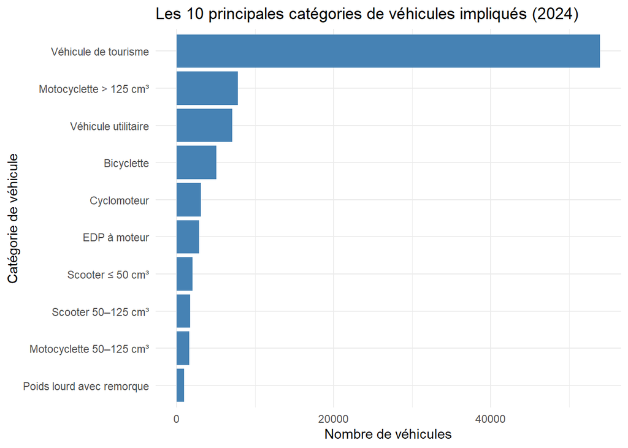

```r
vehicules_top10 <- vehicules_repartition |>
  slice_max(
    order_by = nb_vehicules,
    n = 10
  )

ggplot(vehicules_top10,
       aes(x = reorder(catv_libelle, nb_vehicules),
           y = nb_vehicules)) +
  geom_col(fill = "steelblue") +
  coord_flip() +
  labs(
    title = "Les 10 principales catégories de véhicules impliqués (2024)",
    x = "Catégorie de véhicule",
    y = "Nombre de véhicules"
  ) +
  theme_minimal()
```

### 4.5.3.Répartition des accidents selon le nombre de véhicules impliqués

On avait déjà créé vehicules_acc, qui contient le nombre de véhicules par Num_Acc.On va l’utiliser directement, sans refaire de jointure.

```r
repartition_nb_vehicules <- vehicules_acc |>
  count(nb_vehicules, name = "nb_accidents") |>
  mutate(
    pourcentage = round(
      nb_accidents / sum(nb_accidents) * 100, 2
    )
  ) |>
  arrange(nb_vehicules)

repartition_nb_vehicules
```

```
## # A tibble: 10 × 3
##    nb_vehicules nb_accidents pourcentage
##           <int>        <int>       <dbl>
##  1            1        20780       38.2
##  2            2        29968       55.1
##  3            3         2909        5.35
##  4            4          574        1.06
##  5            5          124        0.23
##  6            6           30        0.06
##  7            7            6        0.01
##  8            8            6        0.01
##  9            9            3        0.01
## 10           11            2        0
```

Interprétation des résultats - 55,09 % des accidents impliquent 2 véhicules (29 968 accidents). - 38,20 % impliquent un seul véhicule (20 780 accidents). - 5,35 % impliquent 3 véhicules. - Les accidents impliquant 4 véhicules ou plus restent très minoritaires. Au total, environ 93,29 % des accidents impliquent un ou deux véhicules.

*Visualisation graphique*

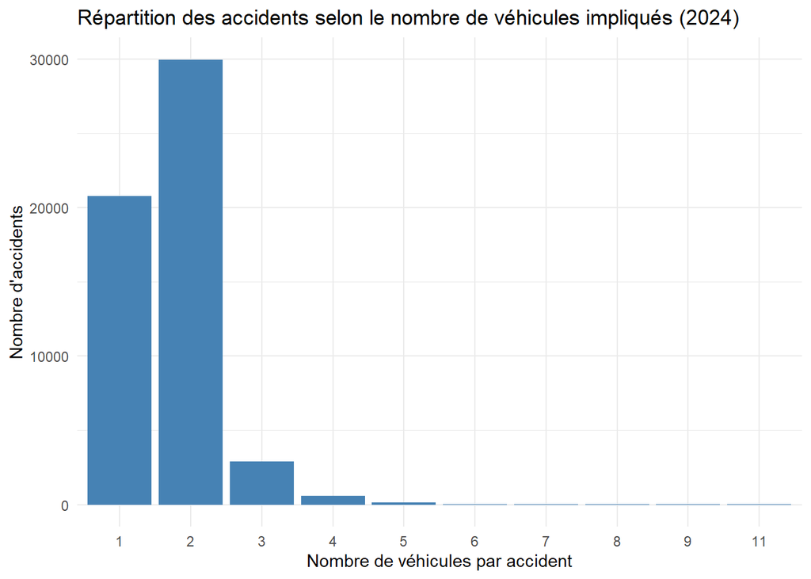

```r
ggplot(repartition_nb_vehicules,
       aes(x = factor(nb_vehicules),
           y = nb_accidents)) +
  geom_col(fill = "steelblue") +
  labs(
    title = "Répartition des accidents selon le nombre de véhicules impliqués (2024)",
    x = "Nombre de véhicules par accident",
    y = "Nombre d'accidents"
  ) +
  theme_minimal()
```

### 4.5.4. Gravité des accidents selon la catégorie du véhicule

On va déterminer, pour chaque catégorie de véhicule, la proportion d’accidents ayant entraîné au moins un décès ou une hospitalisation.

Précision : un accident peut impliquer plusieurs catégories de véhicules. Il pourra donc apparaître dans plusieurs catégories.On ne doit pas compter artificiellement chaque véhicule comme un accident distinct.

```r
gravite_vehicules <- vehicules |>
  distinct(Num_Acc, catv_libelle) |>
  left_join(
    grav_acc |> select(Num_Acc, grave),
    by = "Num_Acc"
  ) |>
  group_by(catv_libelle) |>
  summarise(
    nb_accidents = n_distinct(Num_Acc),
    nb_accidents_graves = n_distinct(Num_Acc[grave %in% TRUE]),
    .groups = "drop"
  ) |>
  mutate(
    pourcentage_graves = round(
      nb_accidents_graves / nb_accidents * 100, 2
    )
  ) |>
  arrange(desc(pourcentage_graves))

gravite_vehicules
```

```
## # A tibble: 32 × 4
##    catv_libelle              nb_accidents nb_accidents_graves pourcentage_graves
##    <chr>                            <int>               <int>              <dbl>
##  1 Non renseigné                        1                   1              100
##  2 Train                               31                  27               87.1
##  3 Tracteur agricole                  268                 201               75
##  4 Quad > 50 cm³                      164                 120               73.2
##  5 Quad ≤ 50 cm³                       12                   8               66.7
##  6 Tracteur routier avec se…          471                 259               55.0
##  7 Poids lourd avec remorque          897                 489               54.5
##  8 Engin spécial                       47                  24               51.1
##  9 Motocyclette > 125 cm³            7574                3550               46.9
## 10 Autocar                            239                 111               46.4
## # ℹ 22 more rows
```

*Visualisation graphique*

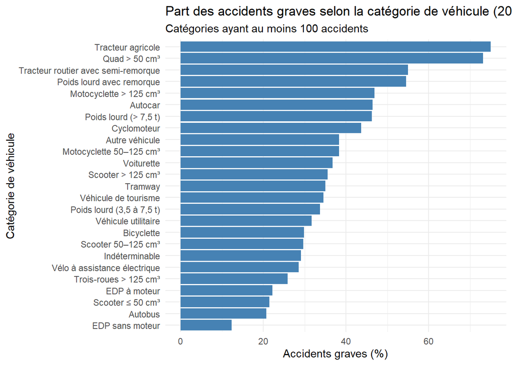

```r
gravite_vehicules_top <- gravite_vehicules |>
  filter(
    nb_accidents >= 100,
    catv_libelle != "Non renseigné"
  ) |>
  arrange(pourcentage_graves)

ggplot(
  gravite_vehicules_top,
  aes(
    x = reorder(catv_libelle, pourcentage_graves),
    y = pourcentage_graves
  )
) +
  geom_col(fill = "steelblue") +
  coord_flip() +
  labs(
    title = "Part des accidents graves selon la catégorie de véhicule (2024)",
    subtitle = "Catégories ayant au moins 100 accidents",
    x = "Catégorie de véhicule",
    y = "Accidents graves (%)"
  ) +
  theme_minimal()
```

**Quatre observations importantes à retenir.**

1. Les véhicules lourds et certains véhicules motorisés présentent des proportions élevées d’accidents graves.
- Tracteur routier avec semi-remorque : 54,99 %.
- Poids lourd avec remorque : 54,52 %.
- Motocyclette de plus de 125 cm³ : 46,87 %.
- Poids lourd de plus de 7,5 tonnes : 46,23 %. Cela met en évidence une proportion importante d’accidents graves parmi les accidents impliquant ces catégories.
2. Les véhicules de tourisme sont très représentés dans les accidents, mais leur proportion d’accidents graves est plus modérée.

Ils représentent 40 718 accidents dans notre tableau, avec 34,55 % d’accidents graves. C’est une distinction importante : une catégorie peut être très fréquente sans présenter le taux de gravité le plus élevé.

3. Certaines catégories affichent des proportions plus faibles.
- EDP sans moteur : 12,30 %.
- Autobus : 20,72 %.
- Scooter de moins de 50 cm³ : 21,46 %.
- EDP à moteur : 22,20 %. Ces chiffres ne signifient pas nécessairement que ces véhicules sont intrinsèquement plus sûrs. Ils décrivent uniquement les accidents observés dans notre base.
4. Les petits effectifs doivent être interprétés avec prudence.

Par exemple : - Train : 27 accidents graves sur 31, soit 87,10 %. - Quad de moins de 50 cm³ : 8 accidents graves sur 12, soit 66,67 %. Ces proportions sont élevées, mais les effectifs sont faibles. Il ne faut donc pas en tirer de conclusions générales.

### 4.5.5. Synthèse de l’axe 4 — Analyse des véhicules

On a réalisé trois analyses :

Analyse Résultat principal Catégories de véhicules 58,17 % de véhicules de tourisme Nombre de véhicules par accident 55,09 % impliquent deux véhicules Gravité selon la catégorie 54,99 % pour les tracteurs routiers avec semi-remorque

Les trois graphiques sont validés. Étape suivante — Synthèse générale de l’analyse exploratoire Nous avons maintenant terminé les quatre axes de notre EDA : 1. Analyse temporelle. 2. Analyse géographique et environnementale. 3. Profil des usagers. 4. Analyse des véhicules.

### 5.PREPARATION DU TABLEAU DE BORD SHINY

*Vérification de la table principale*

```r
dim(accidents)
```

```
## [1] 54402    36
```

```r
n_distinct(accidents$Num_Acc)
```

```
## [1] 54402
```

```r
file.exists("data/accidents_clean.rds")
```

```
## [1] TRUE
```

### 5.1. Synthese generale de l’EDA

On va construire un tableau récapitulatif des indicateurs clés de notre étude, sans refaire les graphiques déjà validés.

*Première manipulation* : créer un tableau avec les principaux indicateurs de notre base.

```r
synthese_globale <- tibble(
  indicateur = c(
    "Nombre total d'accidents",
    "Accidents graves",
    "Accidents mortels",
    "Accidents en agglomération",
    "Accidents hors agglomération",
    "Accidents impliquant 1 véhicule",
    "Accidents impliquant 2 véhicules"
  ),
  valeur = c(
    n_distinct(accidents$Num_Acc),
    sum(accidents$grave, na.rm = TRUE),
    sum(accidents$tue, na.rm = TRUE),
    sum(accidents$agg_libelle == "En agglomération", na.rm = TRUE),
    sum(accidents$agg_libelle == "Hors agglomération", na.rm = TRUE),
    sum(vehicules_acc$nb_vehicules == 1, na.rm = TRUE),
    sum(vehicules_acc$nb_vehicules == 2, na.rm = TRUE)
  )
)

synthese_globale
```

```
## # A tibble: 7 × 2
##   indicateur                       valeur
##   <chr>                             <int>
## 1 Nombre total d'accidents          54402
## 2 Accidents graves                  19658
## 3 Accidents mortels                  3226
## 4 Accidents en agglomération        34010
## 5 Accidents hors agglomération      20392
## 6 Accidents impliquant 1 véhicule   20780
## 7 Accidents impliquant 2 véhicules  29968
```

Attention : un accident grave désigne ici un accident impliquant au moins un usager tué ou hospitalisé. Un accident mortel désigne un accident impliquant au moins un usager décédé.

*Calcul des pourcentages*

```r
synthese_globale <- synthese_globale |>
  mutate(
    pourcentage = round(
      valeur / 54402 * 100,
      2
    )
  )

synthese_globale
```

```
## # A tibble: 7 × 3
##   indicateur                       valeur pourcentage
##   <chr>                             <int>       <dbl>
## 1 Nombre total d'accidents          54402      100
## 2 Accidents graves                  19658       36.1
## 3 Accidents mortels                  3226        5.93
## 4 Accidents en agglomération        34010       62.5
## 5 Accidents hors agglomération      20392       37.5
## 6 Accidents impliquant 1 véhicule   20780       38.2
## 7 Accidents impliquant 2 véhicules  29968       55.1
```

### 5.2.Préparation des conclusions statistiques

```r
names(accidents)
```

```
##  [1] "Num_Acc"           "jour"              "mois"
##  [4] "an"                "hrmn"              "lum"
##  [7] "dep"               "com"               "agg"
## [10] "int"               "atm"               "col"
## [13] "adr"               "lat"               "long"
## [16] "nb_usagers"        "grave"             "tue"
## [19] "nb_Adultes"        "nb_Jeunes adultes" "nb_Seniors"
## [22] "nb_Adolescents"    "nb_Adultes mûrs"   "nb_Enfants"
## [25] "nb_vehicules"      "date"              "heure"
## [28] "minute"            "periode"           "lum_libelle"
## [31] "agg_libelle"       "int_libelle"       "atm_libelle"
## [34] "col_libelle"       "latitude"          "longitude"
```

*Rédaction des principaux enseignements de l’EDA* :

Voici une première synthèse des résultats, qu’on va intégrer à la présentation du projet.

1. Dimension temporelle
- Le mois de juillet enregistre le plus grand nombre d’accidents : 5 209.
- L’heure la plus représentée est 17 h : 4 607 accidents.
- L’après-midi concentre 36,94 % des accidents.
2. Dimension géographique et environnementale
- Paris (75) est le département qui enregistre le plus d’accidents : 4 191.
- 62,52 % des accidents se produisent en agglomération.
- La chaussée est déclarée normale dans 78,12 % des enregistrements de surface.
3. Profil des usagers
- Les hommes représentent 66,99 % des usagers.
- Les adultes de 25 à 44 ans constituent la catégorie d’âge la plus représentée.
- Les seniors présentent une proportion de décès de 6,61 % parmi les usagers de cette catégorie d’âge.
4. Dimension véhicule
- Les véhicules de tourisme représentent 58,17 % des véhicules impliqués.
- 55,09 % des accidents impliquent deux véhicules.
- Les catégories de véhicules présentent des proportions d’accidents graves très différentes. Ces résultats sont descriptifs : ils mettent en évidence des associations et des tendances, mais ne démontrent pas à eux seuls des relations de causalité.

*Rédaction de la synthèse générale* : on va sauvegarder le tableau synthese_globale dans le dossier data/,afin de conserver les indicateurs calculés et de pouvoir les réutiliser plus tard

```r
write.csv(
  synthese_globale,
  "data/synthese_globale.csv",
  row.names = FALSE,
  fileEncoding = "UTF-8"
)
```

```r
file.exists("data/synthese_globale.csv")
```

```
## [1] TRUE
```

*Préparer la structure du projet* Vérification de l’organism des dossiers

```r
list.files()
```

```
## [1] "accidents-routiers.html"  "accidents-routiers.Rmd"
## [3] "accidents-routiers_files" "app"
## [5] "data"                     "projet S.Rproj"
## [7] "R"                        "README.md"
```

### 6.Création des dossiers R et app

```r
dir.create("R", showWarnings = FALSE)
dir.create("app", showWarnings = FALSE)
```

```r
list.files()
```

```
## [1] "accidents-routiers.html"  "accidents-routiers.Rmd"
## [3] "accidents-routiers_files" "app"
## [5] "data"                     "projet S.Rproj"
## [7] "R"                        "README.md"
```

### 6.1.Création du fichier de l’application de R Shiny

```r
file.create("app/app.R")
```

```
## [1] TRUE
```

```r
file.exists("app/app.R")
```

```
## [1] TRUE
```

### 6.2. Vérification de l’installation de Shiny

*Vérification des pakages de shiny*

```r
if (!requireNamespace("shiny", quietly = TRUE)) {
  install.packages("shiny")
}
```

```r
library(shiny)
packageVersion("shiny")
```

```
## [1] '1.14.0'
```

*Installation des packages nécessaires au tableau de bord*

```r
packages <- c(
  "shiny",
  "dplyr",
  "ggplot2",
  "plotly",
  "leaflet",
  "DT",
  "lubridate",
  "readr"
)

packages_manquants <- packages[
  !packages %in% installed.packages()[, "Package"]
]

if (length(packages_manquants) > 0) {
  install.packages(packages_manquants)
}
```

```r
sapply(packages, requireNamespace, quietly = TRUE)
```

```
##     shiny     dplyr   ggplot2    plotly   leaflet        DT lubridate     readr
##      TRUE      TRUE      TRUE      TRUE      TRUE      TRUE      TRUE      TRUE
```

*Définir le contenu de notre tableau de bord*

Avant d’écrire le code, voici la structure que nous allons construire : Accidents de la route en France — 2024 PROJET DATA SCIENCE · BAAC 2024 54 402 Accidents recensés 19 658 Accidents graves 3 226 Accidents mortels 62,52 % En agglomération

Rubriques de navigation - Vue générale - Analyse temporelle - Analyse géographique - Profil des usagers - Analyse des véhicules - Exploration des données

```r
colonnes_app <- c("Num_Acc", "dep", "mois", "date", "heure", "agg", "agg_libelle",
                  "grave", "tue", "latitude", "longitude")
stopifnot(all(colonnes_app %in% names(accidents)),
          n_distinct(accidents$Num_Acc) == nrow(accidents))

dir.create("data", showWarnings = FALSE)
saveRDS(accidents, "data/accidents_clean.rds")
saveRDS(usagers,   "data/usagers_2024.rds")
```